# **Home Credit Default Risk Analysis and Prediction**

## **A Machine Learning Approach Using Historical Credit Behavior**

#### Author: Luis Rito Filipe

#### May, 2026

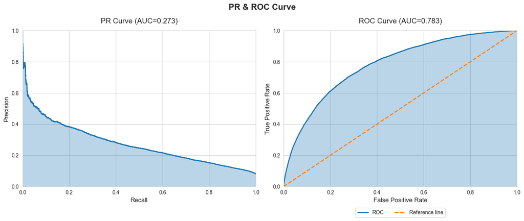

# About The Study

This study addresses the problem of credit default prediction using the Home Credit Default Risk dataset. The objective is to estimate the probability that an applicant will experience payment difficulties based on application information, external credit bureau data, and historical borrowing and repayment behavior. The project combines information from multiple data sources, including application records, external credit history, previous loan applications, installment payments, point-of-sale loans, and credit card balances.

The final objective of the study is not only to develop a predictive model, but also to identify the factors most strongly associated with default risk and evaluate the contribution of different sources of customer information to credit risk assessment. To achieve this, widely used Python libraries for data analysis and machine learning are employed, including tools for data manipulation, visualization, and predictive modeling. The study follows a structured approach, beginning with data preprocessing, followed by exploratory data analysis (EDA), feature engineering and model training, and concluding with model evaluation.

# Summary

This study developed a credit default prediction model using the Home Credit Default Risk dataset. Information from multiple historical credit datasets was consolidated into a unified customer-level dataset through extensive feature engineering and aggregation procedures. The analysis revealed that external credit source variables are the strongest predictors of default risk, consistently dominating both feature importance rankings and SHAP-based interpretability analyses. Historical borrowing behavior, repayment patterns, credit burden indicators, and financial stress measures also provided meaningful predictive signal and substantially improved model performance.

The final model was implemented using LightGBM and achieved a ROC-AUC of approximately 0.7825. The model demonstrated a strong ability to rank applicants according to default risk and achieved a PR-AUC approximately 3.4 times higher than the random baseline. However, the results also indicate that the underlying prediction problem is inherently difficult, as substantial overlap exists between default and non-default applicants. Consequently, the model is more effective at ranking applicants by relative risk than at producing precise binary default classifications.

Model interpretation using SHAP confirmed that external credit information is the primary driver of predictions, complemented by engineered features describing financial pressure, historical borrowing behavior, repayment performance, and applicant socioeconomic characteristics. Overall, the results demonstrate that combining application data with historical credit behavior and domain-driven feature engineering can substantially improve credit risk prediction performance, even in highly imbalanced classification settings.

# About The Dataset

The dataset originates from the Home Credit default risk challenge and consists of multiple relational files describing applicant demographics, financial behavior, and external credit information.

Dataset link: https://www.kaggle.com/competitions/home-credit-default-risk/data

```python
import gc
import pandas as pd
import numpy as np
import matplotlib.pyplot as plt
from phik import phik_matrix
from scipy.optimize import brentq
from plotly.subplots import make_subplots
import seaborn as sns
from sklearn.model_selection import train_test_split
from sklearn.metrics import confusion_matrix, precision_score, recall_score, f1_score, precision_recall_curve, roc_auc_score, roc_curve, average_precision_score, matthews_corrcoef, log_loss, brier_score_loss, r2_score, mean_absolute_error
from sklearn.calibration import calibration_curve
from sklearn.model_selection import RandomizedSearchCV, StratifiedKFold
from lightgbm import LGBMClassifier
from lightgbm import LGBMRegressor
import shap
import warnings

warnings.filterwarnings("ignore")
pd.set_option('display.max_rows', None)
pd.set_option('display.max_columns', None)
pd.set_option('display.max_colwidth', None)

def plot_confusion_matrix(y, y_predict):
    sns.set_style("whitegrid")
    cm = confusion_matrix(y, y_predict)
    plt.figure(figsize=(4, 3))
    ax = sns.heatmap(cm, annot=True, fmt="d", cmap="Blues")
    ax.set_xlabel('Predicted labels', fontsize=11, labelpad=10)
    ax.set_ylabel('True labels', fontsize=11, labelpad=10)
    ax.set_title('Confusion Matrix', fontsize=13, pad=14, fontweight="bold")
    ax.xaxis.set_ticklabels(['Is not default', 'Is default'])
    ax.yaxis.set_ticklabels(['Is not default', 'Is default'])
    plt.tight_layout()
    plt.show()

def plot_feature_correlation(data, cols):
    corr = data.phik_matrix(interval_cols=cols)["Class"].drop("Class").sort_values(ascending=False)
    sns.set_style("whitegrid")

    fig, ax = plt.subplots(figsize=(30, 3.2))
    sns.barplot(
        x=corr.index,
        y=corr.values,
        color=sns.color_palette("Blues", n_colors=5)[3],
        width=0.9,
        ax=ax,
    )

    ax.tick_params(axis='x', rotation=90)
    ax.set_title("Correlation with Class", fontsize=14, fontweight="bold", pad=14)
    ax.set_xlabel(None)
    ax.set_ylabel("Correlation", fontsize=12, labelpad=12)
    ax.axhline(y=0, color="black", linewidth=0.3)
    ax.set_xlim(-1, max(corr.index.nunique(), 10))

    fig.canvas.draw()
    renderer = fig.canvas.get_renderer()
    max_height_px = max(
        label.get_window_extent(renderer=renderer).height
        for label in ax.get_xticklabels()
    )
    dpi = fig.dpi
    extra_height_inch = max_height_px / dpi
    fig.set_size_inches(12, 3 + extra_height_inch)

    plt.tight_layout()
    plt.show()

def plot_feature_correlation_matrix(data):
    cols = data.columns

    corr = data[cols].phik_matrix()
    datalen = len(corr)

    sns.set_style("whitegrid")
    fig, ax = plt.subplots(figsize=(0.65 * datalen, 0.55 * datalen))
    sns.heatmap(
        data=corr,
        annot=True,
        cmap="Blues",
        fmt=".2f",
        ax=ax,
        annot_kws={"size": 9},
        linewidths=0.5
    )

    ax.set_title("Categorical Feature Correlation Matrix", fontsize=14, fontweight="bold", pad=14)
    plt.tight_layout()
    plt.show()
```

# Methodology

- Data Wrangling and Preprocessing
- Exploratory Data Analysis and Feature Evaluation
- Model Training
- Model Evaluation
- SHAP Analysis
- Key Findings
- Limitations
- Conclusions

# Data Wrangling and Preprocessing

The complete dataset is composed of the following files:

- "application_train.csv"
- "bureau.csv"
- "bureau_balance.csv"
- "previous_application.csv"
- "installments_payments.csv"
- "POS_CASH_balance.csv"
- "credit_card_balance.csv"

The preprocessing process began with application_train.csv, which serves as the primary dataset for model development. To support feature understanding and data exploration, summary statistics were reviewed alongside the metadata provided in HomeCredit_columns_description.csv file. This facilitated a structured interpretation of variable definitions, business context, and relationships across the different data sources.

```python
df = pd.read_csv("application_train.csv")
df.info(verbose=False)
```

```
<class 'pandas.core.frame.DataFrame'>
RangeIndex: 307511 entries, 0 to 307510
Columns: 122 entries, SK_ID_CURR to AMT_REQ_CREDIT_BUREAU_YEAR
dtypes: float64(65), int64(41), object(16)
memory usage: 286.2+ MB
```

```python
df.describe(include="all")
```

|  | SK_ID_CURR | TARGET | NAME_CONTRACT_TYPE | CODE_GENDER | FLAG_OWN_CAR | FLAG_OWN_REALTY | CNT_CHILDREN | AMT_INCOME_TOTAL | AMT_CREDIT | AMT_ANNUITY | AMT_GOODS_PRICE | NAME_TYPE_SUITE | NAME_INCOME_TYPE | NAME_EDUCATION_TYPE | NAME_FAMILY_STATUS | NAME_HOUSING_TYPE | REGION_POPULATION_RELATIVE | DAYS_BIRTH | DAYS_EMPLOYED | DAYS_REGISTRATION | DAYS_ID_PUBLISH | OWN_CAR_AGE | FLAG_MOBIL | FLAG_EMP_PHONE | FLAG_WORK_PHONE | FLAG_CONT_MOBILE | FLAG_PHONE | FLAG_EMAIL | OCCUPATION_TYPE | … |
| --- | --- | --- | --- | --- | --- | --- | --- | --- | --- | --- | --- | --- | --- | --- | --- | --- | --- | --- | --- | --- | --- | --- | --- | --- | --- | --- | --- | --- | --- | --- |
| count | 307511.000000 | 307511.000000 | 307511 | 307511 | 307511 | 307511 | 307511.000000 | 3.075110e+05 | 3.075110e+05 | 307499.000000 | 3.072330e+05 | 306219 | 307511 | 307511 | 307511 | 307511 | 307511.000000 | 307511.000000 | 307511.000000 | 307511.000000 | 307511.000000 | 104582.000000 | 307511.000000 | 307511.000000 | 307511.000000 | 307511.000000 | 307511.000000 | 307511.000000 | 211120 | … |
| unique | NaN | NaN | 2 | 3 | 2 | 2 | NaN | NaN | NaN | NaN | NaN | 7 | 8 | 5 | 6 | 6 | NaN | NaN | NaN | NaN | NaN | NaN | NaN | NaN | NaN | NaN | NaN | NaN | 18 | … |
| top | NaN | NaN | Cash loans | F | N | Y | NaN | NaN | NaN | NaN | NaN | Unaccompanied | Working | Secondary / secondary special | Married | House / apartment | NaN | NaN | NaN | NaN | NaN | NaN | NaN | NaN | NaN | NaN | NaN | NaN | Laborers | … |
| freq | NaN | NaN | 278232 | 202448 | 202924 | 213312 | NaN | NaN | NaN | NaN | NaN | 248526 | 158774 | 218391 | 196432 | 272868 | NaN | NaN | NaN | NaN | NaN | NaN | NaN | NaN | NaN | NaN | NaN | NaN | 55186 | … |
| mean | 278180.518577 | 0.080729 | NaN | NaN | NaN | NaN | 0.417052 | 1.687979e+05 | 5.990260e+05 | 27108.573909 | 5.383962e+05 | NaN | NaN | NaN | NaN | NaN | 0.020868 | -16036.995067 | 63815.045904 | -4986.120328 | -2994.202373 | 12.061091 | 0.999997 | 0.819889 | 0.199368 | 0.998133 | 0.281066 | 0.056720 | NaN | … |
| std | 102790.175348 | 0.272419 | NaN | NaN | NaN | NaN | 0.722121 | 2.371231e+05 | 4.024908e+05 | 14493.737315 | 3.694465e+05 | NaN | NaN | NaN | NaN | NaN | 0.013831 | 4363.988632 | 141275.766519 | 3522.886321 | 1509.450419 | 11.944812 | 0.001803 | 0.384280 | 0.399526 | 0.043164 | 0.449521 | 0.231307 | NaN | … |
| min | 100002.000000 | 0.000000 | NaN | NaN | NaN | NaN | 0.000000 | 2.565000e+04 | 4.500000e+04 | 1615.500000 | 4.050000e+04 | NaN | NaN | NaN | NaN | NaN | 0.000290 | -25229.000000 | -17912.000000 | -24672.000000 | -7197.000000 | 0.000000 | 0.000000 | 0.000000 | 0.000000 | 0.000000 | 0.000000 | 0.000000 | NaN | … |
| 25% | 189145.500000 | 0.000000 | NaN | NaN | NaN | NaN | 0.000000 | 1.125000e+05 | 2.700000e+05 | 16524.000000 | 2.385000e+05 | NaN | NaN | NaN | NaN | NaN | 0.010006 | -19682.000000 | -2760.000000 | -7479.500000 | -4299.000000 | 5.000000 | 1.000000 | 1.000000 | 0.000000 | 1.000000 | 0.000000 | 0.000000 | NaN | … |
| 50% | 278202.000000 | 0.000000 | NaN | NaN | NaN | NaN | 0.000000 | 1.471500e+05 | 5.135310e+05 | 24903.000000 | 4.500000e+05 | NaN | NaN | NaN | NaN | NaN | 0.018850 | -15750.000000 | -1213.000000 | -4504.000000 | -3254.000000 | 9.000000 | 1.000000 | 1.000000 | 0.000000 | 1.000000 | 0.000000 | 0.000000 | NaN | … |
| 75% | 367142.500000 | 0.000000 | NaN | NaN | NaN | NaN | 1.000000 | 2.025000e+05 | 8.086500e+05 | 34596.000000 | 6.795000e+05 | NaN | NaN | NaN | NaN | NaN | 0.028663 | -12413.000000 | -289.000000 | -2010.000000 | -1720.000000 | 15.000000 | 1.000000 | 1.000000 | 0.000000 | 1.000000 | 1.000000 | 0.000000 | NaN | … |
| max | 456255.000000 | 1.000000 | NaN | NaN | NaN | NaN | 19.000000 | 1.170000e+08 | 4.050000e+06 | 258025.500000 | 4.050000e+06 | NaN | NaN | NaN | NaN | NaN | 0.072508 | -7489.000000 | 365243.000000 | 0.000000 | 0.000000 | 91.000000 | 1.000000 | 1.000000 | 1.000000 | 1.000000 | 1.000000 | 1.000000 | NaN | … |

An initial inspection of the dataset revealed a substantial number of missing values across several features. Rather than treating these missing observations purely as data quality issues, they were considered potentially informative missingness, meaning that the absence of information itself may carry predictive signal.

Since this work uses exclusively non-linear machine learning models, the presence of missing values does not constitute a major limitation. Tree-based algorithms are generally robust to missing data and can, in some cases, exploit missingness as an informative feature during training. Consequently, imputing missing values using simple statistics such as means, medians, or zeros could distort the original data distribution and potentially remove useful signal. For these reasons, no imputation strategy was applied during preprocessing. This design choice allows the model to directly learn from missingness patterns without introducing additional assumptions through imputation.

However, as a secondary consideration, features with both high predictive importance and a large proportion of missing values were later evaluated to determine whether missing entries could be reliably inferred from other variables. The data preparation stage was therefore limited to basic consistency checks, datatype adjustments, and transformations required for model compatibility. Below is a list of features with missing values.

```python
def missing_values(data):
    missing = data.isna().sum().reset_index(name="Count").sort_values("Count", ascending=False).rename(columns={"index": "Feature"})
    missing = missing[missing["Count"] > 0]
    n = 10
    sections = []
    for i in range(0, len(missing), n):
        section = missing.iloc[i:i+n].reset_index(drop=True)
        section[section.columns[1]] = section[section.columns[1]].astype("Int32")
        section.columns = [f"Feature_{i+1}_{i+10}", f"Count_{i+1}_{i+10}"]
        sections.append(section)
    return pd.concat(sections, axis=1).style.hide(axis="index")
missing_values(df)
```

| Feature_1_10 | Count_1_10 | Feature_11_20 | Count_11_20 | Feature_21_30 | Count_21_30 | Feature_31_40 | Count_31_40 | Feature_41_50 | Count_41_50 | Feature_51_60 | Count_51_60 | Feature_61_70 | Count_61_70 |
| --- | --- | --- | --- | --- | --- | --- | --- | --- | --- | --- | --- | --- | --- |
| COMMONAREA_AVG | 214865 | FLOORSMIN_MODE | 208642 | BASEMENTAREA_MODE | 179943 | WALLSMATERIAL_MODE | 156341 | HOUSETYPE_MODE | 154297 | EXT_SOURCE_3 | 60965 | DEF_30_CNT_SOCIAL_CIRCLE | 1021 |
| COMMONAREA_MODE | 214865 | FLOORSMIN_AVG | 208642 | BASEMENTAREA_MEDI | 179943 | APARTMENTS_AVG | 156061 | FLOORSMAX_MODE | 153020 | AMT_REQ_CREDIT_BUREAU_HOUR | 41519 | OBS_30_CNT_SOCIAL_CIRCLE | 1021 |
| COMMONAREA_MEDI | 214865 | FLOORSMIN_MEDI | 208642 | BASEMENTAREA_AVG | 179943 | APARTMENTS_MEDI | 156061 | FLOORSMAX_AVG | 153020 | AMT_REQ_CREDIT_BUREAU_WEEK | 41519 | EXT_SOURCE_2 | 660 |
| NONLIVINGAPARTMENTS_MEDI | 213514 | YEARS_BUILD_AVG | 204488 | EXT_SOURCE_1 | 173378 | APARTMENTS_MODE | 156061 | FLOORSMAX_MEDI | 153020 | AMT_REQ_CREDIT_BUREAU_MON | 41519 | AMT_GOODS_PRICE | 278 |
| NONLIVINGAPARTMENTS_MODE | 213514 | YEARS_BUILD_MODE | 204488 | NONLIVINGAREA_MODE | 169682 | ENTRANCES_MODE | 154828 | YEARS_BEGINEXPLUATATION_MODE | 150007 | AMT_REQ_CREDIT_BUREAU_YEAR | 41519 | AMT_ANNUITY | 12 |
| NONLIVINGAPARTMENTS_AVG | 213514 | YEARS_BUILD_MEDI | 204488 | NONLIVINGAREA_AVG | 169682 | ENTRANCES_MEDI | 154828 | YEARS_BEGINEXPLUATATION_MEDI | 150007 | AMT_REQ_CREDIT_BUREAU_DAY | 41519 | CNT_FAM_MEMBERS | 2 |
| FONDKAPREMONT_MODE | 210295 | OWN_CAR_AGE | 202929 | NONLIVINGAREA_MEDI | 169682 | ENTRANCES_AVG | 154828 | YEARS_BEGINEXPLUATATION_AVG | 150007 | AMT_REQ_CREDIT_BUREAU_QRT | 41519 | DAYS_LAST_PHONE_CHANGE | 1 |
| LIVINGAPARTMENTS_AVG | 210199 | LANDAREA_MEDI | 182590 | ELEVATORS_AVG | 163891 | LIVINGAREA_AVG | 154350 | TOTALAREA_MODE | 148431 | NAME_TYPE_SUITE | 1292 | nan |  |
| LIVINGAPARTMENTS_MEDI | 210199 | LANDAREA_AVG | 182590 | ELEVATORS_MEDI | 163891 | LIVINGAREA_MEDI | 154350 | EMERGENCYSTATE_MODE | 145755 | DEF_60_CNT_SOCIAL_CIRCLE | 1021 | nan |  |
| LIVINGAPARTMENTS_MODE | 210199 | LANDAREA_MODE | 182590 | ELEVATORS_MODE | 163891 | LIVINGAREA_MODE | 154350 | OCCUPATION_TYPE | 96391 | OBS_60_CNT_SOCIAL_CIRCLE | 1021 | nan |  |

A data quality issue was identified in the feature DAYS_EMPLOYED, which contains a large number of observations with the value 365243. This value is inconsistent with the expected distribution of the variable, as employment duration is otherwise recorded in negative days (relative to the application date). In the original dataset documentation, this value is commonly interpreted as a placeholder for missing or unrecorded employment history.

To address this issue, the value 365243 was treated as a missing indicator and replaced with NaN, allowing the model to handle it consistently with other missing values. This preprocessing step ensures consistency in the representation of missing employment information across the dataset and prevents the model from learning spurious patterns from the sentinel value.

```python
df["DAYS_EMPLOYED"] = np.where(df["DAYS_EMPLOYED"] > 0, np.nan,  df["DAYS_EMPLOYED"])
```

# Exploratory Data Analysis and Feature Evaluation

The exploratory analysis began by training a LightGBM classifier to obtain initial ranking of feature importance across the available variables. The feature importance output was primarily used as a guiding signal for subsequent feature engineering decisions. In particular, many engineered variables in the application dataset were derived from or motivated by the most influential original features identified by the model. This approach was used as an empirical prioritization strategy to focus feature engineering efforts on variables with higher predictive signal. The full feature importance ranking is provided below for reference.

```python
def show_importances_split_by_columns(data):
    importances = data.T
    n = 10
    sections = []
    for i in range(0, len(importances), n):
        section = importances.iloc[i:i+n].reset_index(drop=True)
        section[section.columns[1]] = section[section.columns[1]].astype("Int32")
        section.columns = [f"Feature_{i+1}_{i+10}", f"Importance_{i+1}_{i+10}"]
        sections.append(section)
    return pd.concat(sections, axis=1).style.hide(axis="index")

show_importances_split_by_columns(light_gbm["importances"])
```

| Feature_1_10 | Importance_1_10 | Feature_11_20 | Importance_11_20 | Feature_21_30 | Importance_21_30 | Feature_31_40 | Importance_31_40 | Feature_41_50 | Importance_41_50 | Feature_51_60 | Importance_51_60 | Feature_61_70 | Importance_61_70 | Feature_71_80 | Importance_71_80 | Feature_81_90 | Importance_81_90 | Feature_91_100 | Importance_91_100 | Feature_101_110 | Importance_101_110 |
| --- | --- | --- | --- | --- | --- | --- | --- | --- | --- | --- | --- | --- | --- | --- | --- | --- | --- | --- | --- | --- | --- |
| EXT_SOURCE_3 | 196409 | DAYS_LAST_PHONE_CHANGE | 12199 | LANDAREA_MODE | 3612 | DEF_60_CNT_SOCIAL_CIRCLE | 3085 | OBS_30_CNT_SOCIAL_CIRCLE | 2517 | NONLIVINGAREA_MEDI | 2029 | NONLIVINGAPARTMENTS_MODE | 1417 | ENTRANCES_MEDI | 876 | ELEVATORS_MODE | 287 | FLAG_DOCUMENT_9 | 94 | FLAG_DOCUMENT_19 | 0 |
| EXT_SOURCE_2 | 169561 | DAYS_REGISTRATION | 10266 | APARTMENTS_AVG | 3569 | APARTMENTS_MODE | 3078 | YEARS_BUILD_MODE | 2493 | LANDAREA_MEDI | 1947 | ENTRANCES_MODE | 1342 | AMT_REQ_CREDIT_BUREAU_WEEK | 711 | REG_CITY_NOT_WORK_CITY | 253 | FLAG_DOCUMENT_21 | 75 | FLAG_DOCUMENT_17 | 0 |
| EXT_SOURCE_1 | 73416 | REGION_POPULATION_RELATIVE | 9048 | LANDAREA_AVG | 3556 | AMT_REQ_CREDIT_BUREAU_QRT | 3074 | REG_CITY_NOT_LIVE_CITY | 2351 | FLOORSMIN_AVG | 1898 | YEARS_BUILD_MEDI | 1315 | FLOORSMAX_MODE | 674 | FLAG_EMAIL | 247 | REG_REGION_NOT_WORK_REGION | 45 | FLAG_DOCUMENT_12 | 0 |
| DAYS_EMPLOYED | 48506 | AMT_INCOME_TOTAL | 8210 | DEF_30_CNT_SOCIAL_CIRCLE | 3529 | LIVINGAPARTMENTS_MODE | 3017 | YEARS_BEGINEXPLUATATION_AVG | 2348 | CNT_FAM_MEMBERS | 1777 | ELEVATORS_AVG | 1284 | FLAG_DOCUMENT_18 | 670 | FLAG_DOCUMENT_15 | 243 | FLAG_EMP_PHONE | 33 | FLAG_DOCUMENT_20 | 0 |
| AMT_CREDIT | 30668 | FLAG_DOCUMENT_3 | 8061 | LIVINGAREA_MODE | 3514 | COMMONAREA_AVG | 2795 | BASEMENTAREA_MEDI | 2259 | ENTRANCES_AVG | 1775 | AMT_REQ_CREDIT_BUREAU_MON | 1258 | NONLIVINGAPARTMENTS_MEDI | 649 | FLAG_DOCUMENT_6 | 222 | FLAG_CONT_MOBILE | 0 | nan |  |
| DAYS_BIRTH | 29538 | AMT_REQ_CREDIT_BUREAU_YEAR | 7913 | HOUR_APPR_PROCESS_START | 3451 | LIVINGAPARTMENTS_AVG | 2662 | APARTMENTS_MEDI | 2218 | COMMONAREA_MODE | 1701 | CNT_CHILDREN | 1136 | FLAG_DOCUMENT_13 | 524 | FLOORSMIN_MEDI | 218 | FLAG_MOBIL | 0 | nan |  |
| AMT_GOODS_PRICE | 27119 | REGION_RATING_CLIENT_W_CITY | 6259 | BASEMENTAREA_AVG | 3404 | YEARS_BEGINEXPLUATATION_MEDI | 2661 | COMMONAREA_MEDI | 2135 | FLOORSMAX_AVG | 1700 | FLAG_DOCUMENT_16 | 1008 | FLAG_DOCUMENT_14 | 523 | REG_REGION_NOT_LIVE_REGION | 155 | FLAG_DOCUMENT_10 | 0 | nan |  |
| AMT_ANNUITY | 26661 | LIVINGAREA_AVG | 5440 | BASEMENTAREA_MODE | 3388 | AMT_REQ_CREDIT_BUREAU_DAY | 2630 | FLAG_WORK_PHONE | 2091 | FLOORSMAX_MEDI | 1617 | FLOORSMIN_MODE | 935 | ELEVATORS_MEDI | 466 | LIVE_CITY_NOT_WORK_CITY | 152 | FLAG_DOCUMENT_7 | 0 | nan |  |
| OWN_CAR_AGE | 16617 | YEARS_BEGINEXPLUATATION_MODE | 4367 | LIVINGAREA_MEDI | 3365 | NONLIVINGAREA_MODE | 2564 | YEARS_BUILD_AVG | 2084 | REGION_RATING_CLIENT | 1570 | FLAG_DOCUMENT_8 | 911 | FLAG_DOCUMENT_5 | 418 | FLAG_DOCUMENT_11 | 151 | FLAG_DOCUMENT_4 | 0 | nan |  |
| DAYS_ID_PUBLISH | 14472 | TOTALAREA_MODE | 3850 | NONLIVINGAREA_AVG | 3284 | OBS_60_CNT_SOCIAL_CIRCLE | 2518 | LIVINGAPARTMENTS_MEDI | 2053 | NONLIVINGAPARTMENTS_AVG | 1475 | FLAG_PHONE | 897 | AMT_REQ_CREDIT_BUREAU_HOUR | 311 | LIVE_REGION_NOT_WORK_REGION | 136 | FLAG_DOCUMENT_2 | 0 | nan |  |

In parallel, a phi-k correlation analysis was performed to assess the association between the independent variables and the target variable. Since phi-k captures both linear and non-linear relationships, it provides a useful complement to feature importance measures. As the full correlation matrix contains a large number of variables and is difficult to interpret, it is not included in this document. Instead, the table below presents the phi-k correlation coefficients between each independent variable and the target variable.

```python
def feature_correlation_table(data):
    phik_corr = data.drop(columns="SK_ID_CURR").phik_matrix(interval_cols=df.select_dtypes(include='number'))["TARGET"].drop("TARGET").to_frame().reset_index().rename(columns={"index": "Feature", "TARGET": "Corr"}).sort_values("Corr", ascending=False).round(2)
    n = 10
    sections = []
    for i in range(0, len(phik_corr), n):
        section = phik_corr.iloc[i:i+n].reset_index(drop=True)
        section[section.columns[1]] = section[section.columns[1]]
        section.columns = [f"Feature_{i+1}_{i+10}", f"Corr_{i+1}_{i+10}"]
        sections.append(section)
    return pd.concat(sections, axis=1).style.hide(axis="index").format(precision=2)
feature_correlation_table(df)
```

| Feature_1_10 | Corr_1_10 | Feature_11_20 | Corr_11_20 | Feature_21_30 | Corr_21_30 | Feature_31_40 | Corr_31_40 | Feature_41_50 | Corr_41_50 | Feature_51_60 | Corr_51_60 | Feature_61_70 | Corr_61_70 | Feature_71_80 | Corr_71_80 | Feature_81_90 | Corr_81_90 | Feature_91_100 | Corr_91_100 | Feature_101_110 | Corr_101_110 | Feature_111_120 | Corr_111_120 |
| --- | --- | --- | --- | --- | --- | --- | --- | --- | --- | --- | --- | --- | --- | --- | --- | --- | --- | --- | --- | --- | --- | --- | --- |
| EXT_SOURCE_3 | 0.25 | FLAG_EMP_PHONE | 0.07 | OWN_CAR_AGE | 0.06 | FLAG_DOCUMENT_6 | 0.04 | REGION_RATING_CLIENT_W_CITY | 0.04 | YEARS_BUILD_MEDI | 0.03 | BASEMENTAREA_MEDI | 0.02 | FONDKAPREMONT_MODE | 0.02 | NONLIVINGAPARTMENTS_MODE | 0.01 | REG_REGION_NOT_LIVE_REGION | 0.01 | FLAG_DOCUMENT_17 | 0.00 | FLAG_DOCUMENT_5 | 0.00 |
| EXT_SOURCE_1 | 0.22 | REG_CITY_NOT_LIVE_CITY | 0.07 | DAYS_REGISTRATION | 0.05 | FLAG_WORK_PHONE | 0.04 | REGION_RATING_CLIENT | 0.04 | AMT_ANNUITY | 0.03 | COMMONAREA_MEDI | 0.02 | FLAG_DOCUMENT_16 | 0.02 | CNT_CHILDREN | 0.01 | HOUSETYPE_MODE | 0.01 | YEARS_BEGINEXPLUATATION_AVG | 0.00 | OBS_30_CNT_SOCIAL_CIRCLE | 0.00 |
| EXT_SOURCE_2 | 0.21 | FLAG_DOCUMENT_3 | 0.07 | NAME_HOUSING_TYPE | 0.05 | ELEVATORS_MEDI | 0.04 | APARTMENTS_AVG | 0.04 | ENTRANCES_AVG | 0.03 | COMMONAREA_AVG | 0.02 | FLAG_DOCUMENT_13 | 0.02 | FLAG_DOCUMENT_8 | 0.01 | NONLIVINGAPARTMENTS_MEDI | 0.01 | AMT_INCOME_TOTAL | 0.00 | FLAG_DOCUMENT_10 | 0.00 |
| DAYS_EMPLOYED | 0.10 | DAYS_ID_PUBLISH | 0.07 | LIVE_CITY_NOT_WORK_CITY | 0.05 | REGION_POPULATION_RELATIVE | 0.04 | APARTMENTS_MEDI | 0.03 | ENTRANCES_MEDI | 0.03 | AMT_REQ_CREDIT_BUREAU_YEAR | 0.02 | LANDAREA_MODE | 0.02 | FLAG_DOCUMENT_18 | 0.01 | YEARS_BEGINEXPLUATATION_MODE | 0.01 | LIVE_REGION_NOT_WORK_REGION | 0.00 | FLAG_DOCUMENT_7 | 0.00 |
| OCCUPATION_TYPE | 0.10 | AMT_GOODS_PRICE | 0.06 | NAME_CONTRACT_TYPE | 0.05 | ELEVATORS_MODE | 0.04 | HOUR_APPR_PROCESS_START | 0.03 | LIVINGAPARTMENTS_AVG | 0.03 | LANDAREA_MEDI | 0.02 | NONLIVINGAREA_MEDI | 0.02 | NONLIVINGAPARTMENTS_AVG | 0.01 | FLAG_DOCUMENT_2 | 0.01 | AMT_REQ_CREDIT_BUREAU_DAY | 0.00 | FLAG_DOCUMENT_19 | 0.00 |
| DAYS_BIRTH | 0.10 | FLOORSMAX_AVG | 0.06 | NAME_EDUCATION_TYPE | 0.05 | LIVINGAREA_MEDI | 0.04 | FLAG_OWN_CAR | 0.03 | LIVINGAPARTMENTS_MEDI | 0.03 | BASEMENTAREA_MODE | 0.02 | CNT_FAM_MEMBERS | 0.02 | REG_REGION_NOT_WORK_REGION | 0.01 | FLAG_DOCUMENT_9 | 0.01 | FLAG_DOCUMENT_4 | 0.00 | FLAG_DOCUMENT_12 | 0.00 |
| ORGANIZATION_TYPE | 0.09 | FLOORSMAX_MEDI | 0.06 | FLOORSMIN_MEDI | 0.05 | LIVINGAREA_AVG | 0.04 | APARTMENTS_MODE | 0.03 | WALLSMATERIAL_MODE | 0.03 | LANDAREA_AVG | 0.02 | NONLIVINGAREA_AVG | 0.02 | FLAG_DOCUMENT_15 | 0.01 | FLAG_DOCUMENT_11 | 0.01 | FLAG_MOBIL | 0.00 | AMT_REQ_CREDIT_BUREAU_HOUR | 0.00 |
| NAME_INCOME_TYPE | 0.08 | FLOORSMAX_MODE | 0.06 | FLOORSMIN_MODE | 0.05 | TOTALAREA_MODE | 0.04 | CODE_GENDER | 0.03 | LIVINGAPARTMENTS_MODE | 0.03 | COMMONAREA_MODE | 0.02 | AMT_REQ_CREDIT_BUREAU_MON | 0.02 | FLAG_OWN_REALTY | 0.01 | WEEKDAY_APPR_PROCESS_START | 0.01 | FLAG_CONT_MOBILE | 0.00 | FLAG_DOCUMENT_20 | 0.00 |
| REG_CITY_NOT_WORK_CITY | 0.08 | AMT_CREDIT | 0.06 | FLOORSMIN_AVG | 0.05 | FLAG_PHONE | 0.04 | YEARS_BUILD_AVG | 0.03 | ENTRANCES_MODE | 0.03 | EMERGENCYSTATE_MODE | 0.02 | NONLIVINGAREA_MODE | 0.01 | DEF_30_CNT_SOCIAL_CIRCLE | 0.01 | YEARS_BEGINEXPLUATATION_MEDI | 0.01 | FLAG_EMAIL | 0.00 | AMT_REQ_CREDIT_BUREAU_WEEK | 0.00 |
| DAYS_LAST_PHONE_CHANGE | 0.07 | NAME_FAMILY_STATUS | 0.06 | ELEVATORS_AVG | 0.05 | LIVINGAREA_MODE | 0.04 | YEARS_BUILD_MODE | 0.03 | BASEMENTAREA_AVG | 0.03 | DEF_60_CNT_SOCIAL_CIRCLE | 0.02 | FLAG_DOCUMENT_14 | 0.01 | NAME_TYPE_SUITE | 0.01 | FLAG_DOCUMENT_21 | 0.00 | OBS_60_CNT_SOCIAL_CIRCLE | 0.00 | AMT_REQ_CREDIT_BUREAU_QRT | 0.00 |

Next, the default rate was analyzed with respect to a selected subset of independent variables. The first chart presents the default rate by age bucket. Younger customers are associated with a higher probability of default, suggesting a clear demographic signal in the data. The chart also includes confidence intervals (standard errors) for each bucket. These intervals are wider in the extreme age groups, which is expected due to the smaller number of observations in these buckets, leading to higher statistical uncertainty. This pattern is consistent with typical credit risk behavior, where younger applicants tend to exhibit higher default rates.

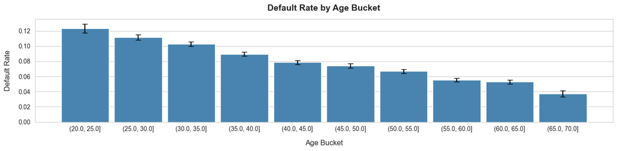

```python
def plot_default_rate_by_age():
    fig, ax = plt.subplots(figsize=(14, 3.5))
    df_aux = df[["DAYS_BIRTH", "TARGET"]].copy()
    df_aux["Age_Years"] = -df_aux["DAYS_BIRTH"] / 365
    df_aux["Age_Bucket"] = pd.cut(df_aux["Age_Years"], bins=np.linspace(20, 70, 11))
    df_aux = df_aux.groupby("Age_Bucket")["TARGET"].agg( default_rate="mean", n="size" )
    df_aux["se"] = np.sqrt( df_aux["default_rate"] * (1 - df_aux["default_rate"]) / df_aux["n"] )
    df_aux["ci_lower"] = df_aux["default_rate"] - 1.96 * df_aux["se"]
    df_aux["ci_upper"] = df_aux["default_rate"] + 1.96 * df_aux["se"]
    df_aux["ci_lower"] = df_aux["ci_lower"].clip(lower=0)
    df_aux["ci_upper"] = df_aux["ci_upper"].clip(upper=1)
    sns.set_style("whitegrid")

    color=sns.color_palette("Blues", n_colors=5)[3]
    sns.barplot(
        x=df_aux["default_rate"].index.astype(str),
        y=df_aux["default_rate"].values,
        color=color,
        width=0.9
    )
    ax.errorbar(
        x=np.arange(len(df_aux)),
        y=df_aux["default_rate"],
        yerr=1.96 * df_aux["se"],
        fmt="none",
        color="black",
        capsize=4
    )
    ax.tick_params(axis='x', rotation=0)
    ax.set_title("Default Rate by Age Bucket", fontsize=14, fontweight="bold", pad=14)
    ax.set_xlabel("Age Bucket", fontsize=12, labelpad=12)
    ax.set_ylabel("Default Rate", fontsize=12, labelpad=12)
    plt.tight_layout()
    plt.show()
plot_default_rate_by_age()
```

The following chart presents the default rate by income type. The results indicate that applicants on maternity leave and unemployed individuals exhibit a higher probability of default compared to other income categories, suggesting that employment status is a relevant risk factor in the dataset. This pattern is consistent with expected credit risk behavior, where unstable employment situations are linked to higher default risk.

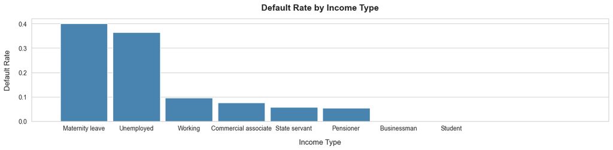

```python
def plot_default_rate_by_income_type():
    fig, ax = plt.subplots(figsize=(14, 3.5))
    df_aux = df[["NAME_INCOME_TYPE", "TARGET"]].copy()
    name_income_type_default = df_aux.groupby("NAME_INCOME_TYPE")["TARGET"].mean().sort_values(ascending=False)
    color=sns.color_palette("Blues", n_colors=5)[3]
    sns.set_style("whitegrid")
    sns.barplot(
        x=name_income_type_default.index.astype(str),
        y=name_income_type_default.values,
        color=color,
        width=0.9
    )
    ax.tick_params(axis='x', rotation=0)
    ax.set_title("Default Rate by Income Type", fontsize=14, fontweight="bold", pad=14)
    ax.set_xlabel("Income Type", fontsize=12, labelpad=12)
    ax.set_ylabel("Default Rate", fontsize=12, labelpad=12)
    ax.set_xlim(-1, max(name_income_type_default.index.nunique(), 10))
    plt.tight_layout()
    plt.show()
plot_default_rate_by_income_type()
```

The following chart presents the default rate by the ratio of years employed to age, computed in buckets. The results indicate that applicants with a lower employment-to-age ratio exhibit a higher probability of default compared to applicants with higher ratios. This finding suggests that employment stability, measured relative to the applicant's age, is associated with lower credit risk.

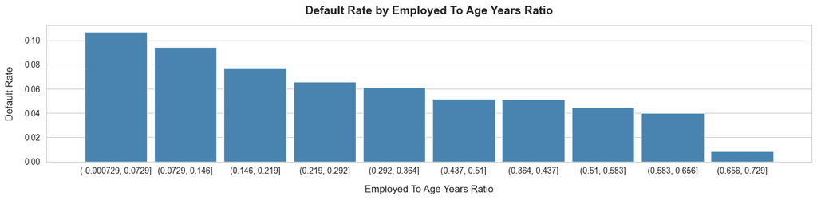

```python
def plot_default_rate_by_years_employed_to_age_ratio():
    fig, ax = plt.subplots(figsize=(14, 3.5))
    df_aux = df[["DAYS_BIRTH", "DAYS_EMPLOYED", "TARGET"]].copy()
    df_aux["Employed_Years"] = -df_aux["DAYS_EMPLOYED"] / 365
    df_aux["Age_Years"] = -df_aux["DAYS_BIRTH"] / 365
    df_aux["Employed_To_Age_Years_Bucket"] = (df_aux["Employed_Years"] / df_aux["Age_Years"])
    df_aux["Employed_To_Age_Years_Bucket"] = pd.cut(df_aux["Employed_To_Age_Years_Bucket"], bins=10, ordered=True)
    employed_to_age_years_ratio_default = df_aux.groupby("Employed_To_Age_Years_Bucket", observed=True)["TARGET"].mean().sort_values(ascending=False)

    color=sns.color_palette("Blues", n_colors=5)[3]
    sns.barplot(
        x=employed_to_age_years_ratio_default.index.astype(str),
        y=employed_to_age_years_ratio_default.values,
        color=color,
        width=0.9
    )
    ax.tick_params(axis='x', rotation=0)
    ax.set_title("Default Rate by Employed To Age Years Ratio", fontsize=14, fontweight="bold", pad=14)
    ax.set_xlabel("Employed To Age Years Ratio", fontsize=12, labelpad=12)
    ax.set_ylabel("Default Rate", fontsize=12, labelpad=12)
    ax.set_xlim(-1, max(employed_to_age_years_ratio_default.index.nunique(), 10))
    plt.tight_layout()
    plt.show()
plot_default_rate_by_years_employed_to_age_ratio()
```

The following chart presents the default rate by loan contract type. The results indicate that applicants with cash loans exhibit a higher probability of default compared to those with revolving loans. This suggests that loan product type is associated with different risk profiles, potentially reflecting differences in credit structure and repayment flexibility.

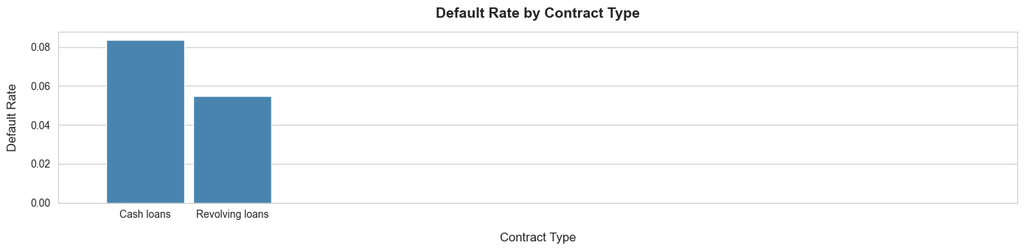

```python
def plot_default_rate_by_contract_type():
    fig, ax = plt.subplots(figsize=(14, 3.5))
    df_aux = df[["NAME_CONTRACT_TYPE", "TARGET"]].copy()
    name_income_type_default = df_aux.groupby("NAME_CONTRACT_TYPE")["TARGET"].mean().sort_values(ascending=False)

    color=sns.color_palette("Blues", n_colors=5)[3]
    sns.barplot(
        x=name_income_type_default.index.astype(str),
        y=name_income_type_default.values,
        color=color,
        width=0.9
    )
    ax.tick_params(axis='x', rotation=0)
    ax.set_title("Default Rate by Contract Type", fontsize=14, fontweight="bold", pad=14)
    ax.set_xlabel("Contract Type", fontsize=12, labelpad=12)
    ax.set_ylabel("Default Rate", fontsize=12, labelpad=12)
    ax.set_xlim(-1, max(name_income_type_default.index.nunique(), 10))
    plt.tight_layout()
    plt.show()
plot_default_rate_by_contract_type()
```

The following chart presents the default rate by occupation type. The results indicate that low-skill laborers stand out as the category with the highest probability of default compared to other occupation types. The remaining categories can be broadly divided into two subgroups: from drivers to cleaning staff, with a default rate of approximately 0.10, and from realty agents to accountants, with a lower average default rate of approximately 0.0625. This pattern suggests that less stable and potentially lower-income occupations are associated with a higher probability of default. This aligns with expected credit risk behavior, where occupational stability is a key determinant of default probability.

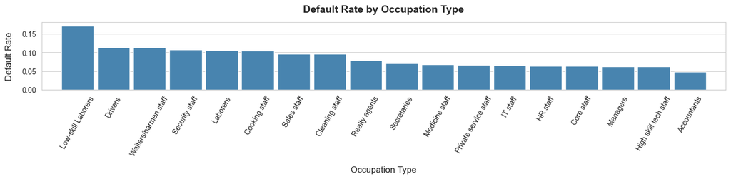

```python
def plot_default_rate_by_occupation_type():
    fig, ax = plt.subplots(figsize=(14, 3.5))
    df_aux = df[["OCCUPATION_TYPE", "TARGET"]].copy()
    name_income_type_default = df_aux.groupby("OCCUPATION_TYPE")["TARGET"].mean().sort_values(ascending=False)

    color=sns.color_palette("Blues", n_colors=5)[3]
    sns.barplot(
        x=name_income_type_default.index.astype(str),
        y=name_income_type_default.values,
        color=color,
        width=0.9
    )
    ax.tick_params(axis='x', rotation=60)
    ax.set_title("Default Rate by Occupation Type", fontsize=14, fontweight="bold", pad=14)
    ax.set_xlabel("Occupation Type", fontsize=12, labelpad=12)
    ax.set_ylabel("Default Rate", fontsize=12, labelpad=12)
    ax.set_xlim(-1, max(name_income_type_default.index.nunique(), 10))
    plt.tight_layout()
    plt.show()
plot_default_rate_by_occupation_type()
```

The following chart presents the default rate by the ratio of AMT_ANNUITY to AMT_INCOME_TOTAL, computed in buckets. This ratio is used as a proxy for applicants’ monthly financial burden relative to their income. The results indicate that higher annuity-to-income ratios are associated with an increased probability of default, suggesting that higher financial strain is a relevant risk factor in the dataset. This finding is consistent with credit risk intuition, where higher debt burden relative to income increases the likelihood of repayment difficulties.

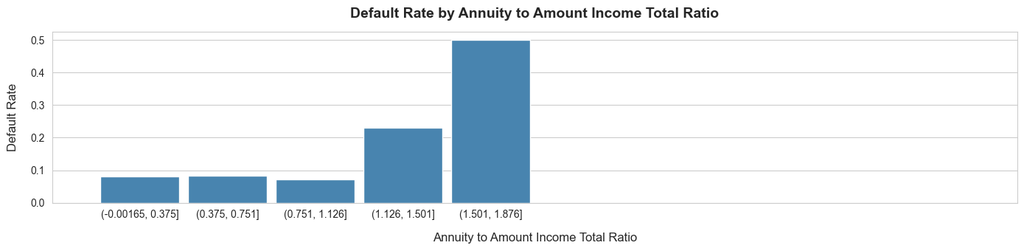

```python
def plot_default_rate_by_annuity_to_amount_income_total_ratio():
    fig, ax = plt.subplots(figsize=(14, 3.5))
    df_aux = df[["AMT_INCOME_TOTAL", "AMT_ANNUITY", "TARGET"]].copy()
    annuity_to_income = df_aux["AMT_ANNUITY"] / df_aux["AMT_INCOME_TOTAL"]
    df_aux["Annuity_To_Income"] = pd.cut(annuity_to_income, bins=5, ordered=True)
    annuity_to_income_default = df_aux.groupby("Annuity_To_Income", observed=True)["TARGET"].mean()

    color=sns.color_palette("Blues", n_colors=5)[3]
    sns.barplot(
        x=annuity_to_income_default.index.astype(str),
        y=annuity_to_income_default.values,
        color=color,
        width=0.9
    )
    ax.tick_params(axis='x', rotation=0)
    ax.set_title("Default Rate by Annuity to Amount Income Total Ratio", fontsize=14, fontweight="bold", pad=14)
    ax.set_xlabel("Annuity to Amount Income Total Ratio", fontsize=12, labelpad=12)
    ax.set_ylabel("Default Rate", fontsize=12, labelpad=12)
    ax.set_xlim(-1, max(annuity_to_income_default.index.nunique(), 10))
    plt.tight_layout()
    plt.show()
plot_default_rate_by_annuity_to_amount_income_total_ratio()
```

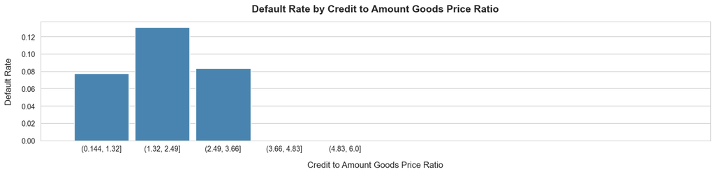

```python
def plot_default_rate_by_credit_to_amount_goods_price_ratio():
    fig, ax = plt.subplots(figsize=(14, 3.5))
    df_aux = df[["AMT_CREDIT", "AMT_GOODS_PRICE", "TARGET"]].copy()
    credit_to_goods_price = df_aux["AMT_CREDIT"] / df_aux["AMT_GOODS_PRICE"]
    df_aux["Credit_To_Goods_Price"] = pd.cut(credit_to_goods_price, bins=5, ordered=True)
    credit_to_goods_price_default = df_aux.groupby("Credit_To_Goods_Price", observed=True)["TARGET"].mean()

    color=sns.color_palette("Blues", n_colors=5)[3]
    sns.barplot(
        x=credit_to_goods_price_default.index.astype(str),
        y=credit_to_goods_price_default.values,
        color=color,
        width=0.9
    )
    ax.tick_params(axis='x', rotation=0)
    ax.set_title("Default Rate by Credit to Amount Goods Price Ratio", fontsize=14, fontweight="bold", pad=14)
    ax.set_xlabel("Credit to Amount Goods Price Ratio", fontsize=12, labelpad=12)
    ax.set_ylabel("Default Rate", fontsize=12, labelpad=12)
    ax.set_xlim(-1, max(credit_to_goods_price_default.index.nunique(), 10))
    plt.tight_layout()
    plt.show()
plot_default_rate_by_credit_to_amount_goods_price_ratio()
```

Given the sparse nature of the FLAG_DOCUMENT_ variables and their limited individual predictive signal, a feature aggregation strategy was applied. All document-related binary indicators, except FLAG_DOCUMENT_3, were combined into a single summary feature named Docs_Ratio, defined as the proportion of provided documents per applicant. This transformation preserves information about overall documentation completeness while reducing dimensionality and feature sparsity. Following this step, the original FLAG_DOCUMENT_ variables were removed from the dataset. This feature captures the applicant’s level of engagement in the application process, which may be indirectly associated with creditworthiness. FLAG_DOCUMENT_3 was ranked among the most important features by LightGBM and also exhibits a strong association with the target variable according to the phi-k correlation matrix. Consequently, it was excluded from the Docs_Ratio aggregation and retained as a standalone feature.

A set of engineered features was created to capture different aspects of applicants’ financial structure, including income per family member, goods price relative to income, credit amount relative to income, annuity relative to income, credit-to-goods-price ratio, and an estimate of loan duration. These variables aim to summarize key dimensions of credit risk, such as monthly repayment burden, indebtedness level, and loan term structure. These engineered ratios are commonly used in credit risk modeling as they normalize raw monetary variables and enable more stable comparisons across applicants with different income levels.

The categorical feature OCCUPATION_TYPE was transformed by grouping occupations into higher- and lower-stability categories, where potentially less stable jobs were encoded as 1 and the remaining categories as 0. A new feature representing the ratio of days employed to age was created to capture employment stability relative to the applicant's age. External score variables were combined into a single weighted score based on feature importance derived from an initial LightGBM baseline model. In the categorical feature CODE_GENDER, missing values labeled as “XNA” were treated as NaN, and the variable was one-hot encoded, resulting in the features Is_Male and Is_Female.

```python
df = df.rename(columns={"TARGET": "Class"})
to_drop = []

df["Income_Per_Fam_Member"] = df["AMT_INCOME_TOTAL"] / df["CNT_FAM_MEMBERS"]
df["Goods_Price_Per_Income_Ratio"] = df["AMT_GOODS_PRICE"] / df["AMT_INCOME_TOTAL"]
df["Credit_Income_Ratio"] = df["AMT_CREDIT"] / df["AMT_INCOME_TOTAL"]
df["Annuity_Income_Ratio"] = df["AMT_ANNUITY"] / df["AMT_INCOME_TOTAL"]
df["Credit_Goods_Ratio"] = df["AMT_CREDIT"] / df["AMT_GOODS_PRICE"]
df["Loan_Term_Estimate"] = df["AMT_CREDIT"] / df["AMT_ANNUITY"]

df["Occupation"] = np.where(df["OCCUPATION_TYPE"].isna(), np.nan, np.where(df["OCCUPATION_TYPE"].isin(["Laborers", "Drivers", "Cleaning staff", "Cooking staff", "Private service staff", "Security staff", "Waiters/barmen staff", "Low-skill Laborers"]), 1, 0))

df["Employed_To_Birth_Ratio"] = df["DAYS_EMPLOYED"] / df["DAYS_BIRTH"]

df["Ext_Source_1_Missing"] = df["EXT_SOURCE_1"].isnull().astype(int)
df["Ext_Source_Weighted"] = ( (0.17 * df["EXT_SOURCE_1"]) + (0.39 * df["EXT_SOURCE_2"]) + (0.44 * df["EXT_SOURCE_3"]))

df["CODE_GENDER"] = df["CODE_GENDER"].replace('XNA', np.nan)
code_gender = pd.get_dummies(df["CODE_GENDER"], dtype=int).rename(columns={ 'M': 'Is_Male', 'F': 'Is_Female' })
df = pd.concat([df, code_gender], axis=1)
to_drop.append("CODE_GENDER")

df["Higher_Education"] = ( df["NAME_EDUCATION_TYPE"] == "Higher education").astype(int)
to_drop.append("NAME_EDUCATION_TYPE")

name_income_type = pd.get_dummies(df["NAME_INCOME_TYPE"], dtype=int)
df = pd.concat([df, name_income_type], axis=1)

name_contract_type = pd.get_dummies(df["NAME_CONTRACT_TYPE"], dtype=int)
df = pd.concat([df, name_contract_type], axis=1)

df["Total_Area_Mode"] = df["TOTALAREA_MODE"]
df["Living_Nonliving_Area_Ratio"] = df["LIVINGAREA_MODE"] / df["NONLIVINGAREA_MODE"].replace(0, np.nan)
building_cols = [c for c in df.columns if any(key in c for key in ["_AVG", "_MEDI", "_MODE"]) and c not in ["ELEVATORS_AVG", "FLOORSMAX_AVG", "FLOORSMIN_AVG", "FLOORSMAX_MODE", "FLOORSMIN_MODE", "FLOORSMAX_MEDI", "FLOORSMIN_MEDI"]]
to_drop.extend(building_cols)

living_working_city_region_cols = ["WEEKDAY_APPR_PROCESS_START", "REG_REGION_NOT_LIVE_REGION", "REG_REGION_NOT_WORK_REGION", "LIVE_REGION_NOT_WORK_REGION"]
to_drop.extend(living_working_city_region_cols)

social_circle_cols = ["OBS_30_CNT_SOCIAL_CIRCLE", "OBS_60_CNT_SOCIAL_CIRCLE", "REG_REGION_NOT_WORK_REGION", "DEF_30_CNT_SOCIAL_CIRCLE"]
to_drop.extend(living_working_city_region_cols)

doc_cols = [c for c in df.columns if "FLAG_DOCUMENT_" in c and c != "FLAG_DOCUMENT_3"]
df["Docs_Ratio"] = df[doc_cols].mean(axis=1)
to_drop.extend(doc_cols)

contact_cols = [ "FLAG_MOBIL", "FLAG_PHONE", "FLAG_CONT_MOBILE" ]
df["Contact_Availability_Score"] = df[contact_cols].mean(axis=1)
to_drop.extend(contact_cols)

to_drop.extend(["FLAG_OWN_CAR", "FLAG_OWN_REALTY"])

amt_req_credit_bureau_cols = [c for c in df.columns if "AMT_REQ_CREDIT_BUREAU_" in c and c not in ["AMT_REQ_CREDIT_BUREAU_MON", "AMT_REQ_CREDIT_BUREAU_YEAR"]]
to_drop.extend(amt_req_credit_bureau_cols)

customer_profile_cols = ["CNT_CHILDREN", "NAME_TYPE_SUITE", "NAME_INCOME_TYPE", "NAME_CONTRACT_TYPE", "OCCUPATION_TYPE", "NAME_HOUSING_TYPE", "NAME_FAMILY_STATUS", "ORGANIZATION_TYPE"]
for col in df.columns:
    if any(key in col for key in customer_profile_cols):
        to_drop.append(col)
df = df.drop(columns=to_drop)
```

The summary statistics of the original features retained and the features engineered in this phase is presentd below. Features in upper case are original features. Features with mixed upper and lower case are features engineered.

```python
df.describe()
```

|  | SK_ID_CURR | Class | AMT_INCOME_TOTAL | AMT_CREDIT | AMT_ANNUITY | AMT_GOODS_PRICE | REGION_POPULATION_RELATIVE | DAYS_BIRTH | DAYS_EMPLOYED | DAYS_REGISTRATION | DAYS_ID_PUBLISH | OWN_CAR_AGE | FLAG_EMP_PHONE | FLAG_WORK_PHONE | FLAG_EMAIL | CNT_FAM_MEMBERS | REGION_RATING_CLIENT | REGION_RATING_CLIENT_W_CITY | HOUR_APPR_PROCESS_START | REG_CITY_NOT_LIVE_CITY | REG_CITY_NOT_WORK_CITY | LIVE_CITY_NOT_WORK_CITY | EXT_SOURCE_1 | EXT_SOURCE_2 | EXT_SOURCE_3 | ELEVATORS_AVG | FLOORSMAX_AVG | FLOORSMIN_AVG | FLOORSMAX_MODE | … |
| --- | --- | --- | --- | --- | --- | --- | --- | --- | --- | --- | --- | --- | --- | --- | --- | --- | --- | --- | --- | --- | --- | --- | --- | --- | --- | --- | --- | --- | --- | --- |
| count | 307511.000000 | 307511.000000 | 3.075110e+05 | 3.075110e+05 | 307499.000000 | 3.072330e+05 | 307511.000000 | 307511.000000 | 252137.000000 | 307511.000000 | 307511.000000 | 104582.000000 | 307511.000000 | 307511.000000 | 307511.000000 | 307509.000000 | 307511.000000 | 307511.000000 | 307511.000000 | 307511.000000 | 307511.000000 | 307511.000000 | 134133.000000 | 3.068510e+05 | 246546.000000 | 143620.000000 | 154491.000000 | 98869.000000 | 154491.000000 | … |
| mean | 278180.518577 | 0.080729 | 1.687979e+05 | 5.990260e+05 | 27108.573909 | 5.383962e+05 | 0.020868 | -16036.995067 | -2384.169325 | -4986.120328 | -2994.202373 | 12.061091 | 0.819889 | 0.199368 | 0.056720 | 2.152665 | 2.052463 | 2.031521 | 12.063419 | 0.078173 | 0.230454 | 0.179555 | 0.502130 | 5.143927e-01 | 0.510853 | 0.078942 | 0.226282 | 0.231894 | 0.222315 | … |
| std | 102790.175348 | 0.272419 | 2.371231e+05 | 4.024908e+05 | 14493.737315 | 3.694465e+05 | 0.013831 | 4363.988632 | 2338.360162 | 3522.886321 | 1509.450419 | 11.944812 | 0.384280 | 0.399526 | 0.231307 | 0.910682 | 0.509034 | 0.502737 | 3.265832 | 0.268444 | 0.421124 | 0.383817 | 0.211062 | 1.910602e-01 | 0.194844 | 0.134576 | 0.144641 | 0.161380 | 0.143709 | … |
| min | 100002.000000 | 0.000000 | 2.565000e+04 | 4.500000e+04 | 1615.500000 | 4.050000e+04 | 0.000290 | -25229.000000 | -17912.000000 | -24672.000000 | -7197.000000 | 0.000000 | 0.000000 | 0.000000 | 0.000000 | 1.000000 | 1.000000 | 1.000000 | 0.000000 | 0.000000 | 0.000000 | 0.000000 | 0.014568 | 8.173617e-08 | 0.000527 | 0.000000 | 0.000000 | 0.000000 | 0.000000 | … |
| 25% | 189145.500000 | 0.000000 | 1.125000e+05 | 2.700000e+05 | 16524.000000 | 2.385000e+05 | 0.010006 | -19682.000000 | -3175.000000 | -7479.500000 | -4299.000000 | 5.000000 | 1.000000 | 0.000000 | 0.000000 | 2.000000 | 2.000000 | 2.000000 | 10.000000 | 0.000000 | 0.000000 | 0.000000 | 0.334007 | 3.924574e-01 | 0.370650 | 0.000000 | 0.166700 | 0.083300 | 0.166700 | … |
| 50% | 278202.000000 | 0.000000 | 1.471500e+05 | 5.135310e+05 | 24903.000000 | 4.500000e+05 | 0.018850 | -15750.000000 | -1648.000000 | -4504.000000 | -3254.000000 | 9.000000 | 1.000000 | 0.000000 | 0.000000 | 2.000000 | 2.000000 | 2.000000 | 12.000000 | 0.000000 | 0.000000 | 0.000000 | 0.505998 | 5.659614e-01 | 0.535276 | 0.000000 | 0.166700 | 0.208300 | 0.166700 | … |
| 75% | 367142.500000 | 0.000000 | 2.025000e+05 | 8.086500e+05 | 34596.000000 | 6.795000e+05 | 0.028663 | -12413.000000 | -767.000000 | -2010.000000 | -1720.000000 | 15.000000 | 1.000000 | 0.000000 | 0.000000 | 3.000000 | 2.000000 | 2.000000 | 14.000000 | 0.000000 | 0.000000 | 0.000000 | 0.675053 | 6.636171e-01 | 0.669057 | 0.120000 | 0.333300 | 0.375000 | 0.333300 | … |
| max | 456255.000000 | 1.000000 | 1.170000e+08 | 4.050000e+06 | 258025.500000 | 4.050000e+06 | 0.072508 | -7489.000000 | 0.000000 | 0.000000 | 0.000000 | 91.000000 | 1.000000 | 1.000000 | 1.000000 | 20.000000 | 3.000000 | 3.000000 | 23.000000 | 1.000000 | 1.000000 | 1.000000 | 0.962693 | 8.549997e-01 | 0.896010 | 1.000000 | 1.000000 | 1.000000 | 1.000000 | … |

External credit history information was summarized using a set of customer-level features derived from the bureau.csv and bureau_balance.csv datasets. These features capture different aspects of historical credit behavior, including the length of outstanding credit records (BB_Months_Outstanding), recent delinquency patterns (BB_DPD_6_M_Ratio and BB_DPD_Max), credit extensions (B_Cnt_Credit_Prolong), and overdue debt amounts (B_Amt_Credit_Sum_Overdue). Special care was taken when processing the bureau status categories, as some values represent closed accounts or missing observations rather than delinquency events. The resulting features were aggregated at the customer level and incorporated into the modeling dataset. Summary statistics for the engineered external credit history features are presented below.

```python
bureau_bal = pd.read_csv("bureau_balance.csv")
bureau_bal["STATUS"] = np.where( bureau_bal["STATUS"].isin(["X", "C"]), np.nan, pd.to_numeric(bureau_bal["STATUS"], errors="coerce") )
bureau_bal = bureau_bal.sort_values(["SK_ID_BUREAU", "MONTHS_BALANCE"])
bureau_bal_agg = bureau_bal.groupby("SK_ID_BUREAU").agg(
    BB_Months_Outstanding_Max=("MONTHS_BALANCE", "max"),
    BB_DPD_6_M_Ratio=("STATUS", lambda x: (x.iloc[-6:] > 0).mean()),
    BB_DPD_Max=("STATUS", "max")
).reset_index()

bureau = pd.read_csv("bureau.csv")
bureau = bureau.merge(bureau_bal_agg, on="SK_ID_BUREAU", how="left")

bureau_by_customer = bureau.groupby("SK_ID_CURR").agg(
    BB_Months_Outstanding=("BB_Months_Outstanding_Max", "sum"),
    BB_DPD_6_M_Ratio=("BB_DPD_6_M_Ratio", "max"),
    BB_DPD_Max=("BB_DPD_Max", "max"),
    B_Cnt_Credit_Prolong=("CNT_CREDIT_PROLONG", "sum"),
    B_Amt_Credit_Sum_Overdue=("AMT_CREDIT_SUM_OVERDUE", "sum")
).reset_index()
del bureau_bal, bureau_bal_agg, bureau
gc.collect()
bureau_by_customer.describe()
```

|  | SK_ID_CURR | BB_Months_Outstanding | BB_DPD_6_M_Ratio | BB_DPD_Max | B_Cnt_Credit_Prolong | B_Amt_Credit_Sum_Overdue |
| --- | --- | --- | --- | --- | --- | --- |
| count | 305811.000000 | 305811.000000 | 134542.000000 | 130773.000000 | 305811.000000 | 3.058110e+05 |
| mean | 278047.300091 | -15.352257 | 0.044967 | 0.529658 | 0.035980 | 2.127933e+02 |
| std | 102849.568343 | 49.444611 | 0.140251 | 0.942016 | 0.232951 | 1.569161e+04 |
| min | 100001.000000 | -2030.000000 | 0.000000 | 0.000000 | 0.000000 | 0.000000e+00 |
| 25% | 188878.500000 | 0.000000 | 0.000000 | 0.000000 | 0.000000 | 0.000000e+00 |
| 50% | 277895.000000 | 0.000000 | 0.000000 | 0.000000 | 0.000000 | 0.000000e+00 |
| 75% | 367184.500000 | 0.000000 | 0.000000 | 1.000000 | 0.000000 | 0.000000e+00 |
| max | 456255.000000 | 0.000000 | 1.000000 | 5.000000 | 9.000000 | 3.756681e+06 |

The following chart presents the phi-k correlation between the engineered bureau features and the target variable (Class). The phi-k correlation coefficient was selected because it captures both linear and non-linear relationships between variables. The results indicate that BB_DPD_6_M_Ratio and BB_DPD_Max stand out as the features most strongly associated with the target variable. This suggests that recent delinquency behavior and the maximum historical delinquency observed in external credit records contain substantial predictive information regarding default risk.

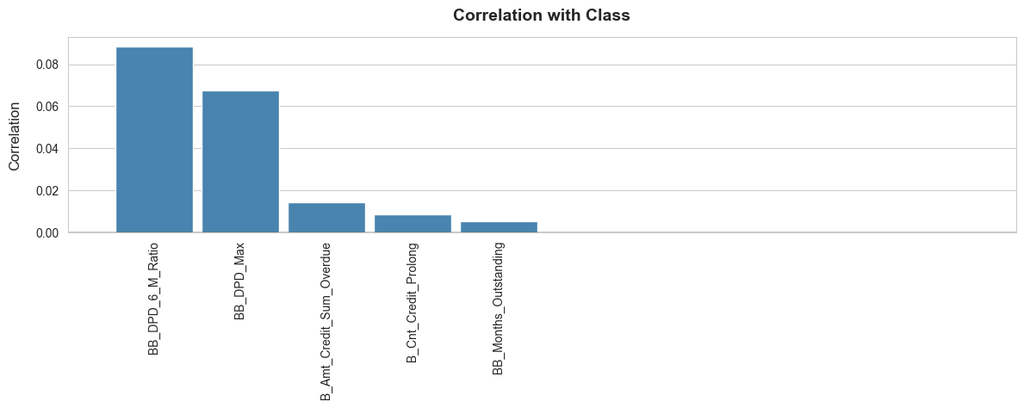

```python
df_bur = bureau_by_customer
df_bur = df_bur.merge(df[["Class", "SK_ID_CURR"]], on="SK_ID_CURR", how="left").drop(columns="SK_ID_CURR")

plot_feature_correlation(df_bur, [c for c in df_bur.columns])
```

Historical borrowing behavior was summarized using a set of customer-level features derived from the previous_application.csv dataset. These features capture different aspects of prior credit activity, including the number of previous applications (PA_Count), historical credit amounts (PA_Credit_Mean and PA_Credit_Max), application recency (PA_Days_Decision_Last, PA_Days_Decision_Min, and PA_Days_Decision_Mean), down-payment burden (PA_Down_Payment_Burden), estimated borrowing costs (PA_Total_Interest_Amt, PA_Estimated_Weighted_Monthly_Rate, and PA_Diff_Monthly_Rate), and the outcomes of previous applications (PA_Approved, PA_Canceled, and PA_Refused).

These engineered features emerged as some of the strongest predictors in the final model, highlighting the importance of applicants’ historical borrowing behavior and prior interactions with the lending process as indicators of future default risk.

Summary statistics for the engineered historical borrowing behavior features are presented below.

```python
prev_appl = pd.read_csv("previous_application.csv")
def estimate_rate_row(credit, annuity, n):
    if credit <= 0 or annuity <= 0 or n <= 0:
        return np.nan

    def f(r):
        return annuity - credit * (
            r * (1 + r) ** n
        ) / (
            (1 + r) ** n - 1
        )

    try:
        return brentq(f, 1e-6, 5)
    except:
        return np.nan

def estimate_monthly_rate(prev_appl):
    mask = (prev_appl["AMT_CREDIT"] > 0) & (prev_appl["AMT_ANNUITY"] > 0) & (prev_appl["CNT_PAYMENT"] > 0)
    prev_appl = prev_appl[mask].copy()
    prev_appl["PA_Estimated_Monthly_Rate"] = prev_appl.apply(
        lambda row: estimate_rate_row(
            row["AMT_CREDIT"],
            row["AMT_ANNUITY"],
            row["CNT_PAYMENT"]
        ),
        axis=1
    )

    return prev_appl

prev_appl = estimate_monthly_rate(prev_appl)
prev_appl = prev_appl.sort_values(["SK_ID_CURR", "DAYS_DECISION"])
prev_appl["PA_Amt_Credit_x_Rate"] = prev_appl["AMT_CREDIT"] * prev_appl["PA_Estimated_Monthly_Rate"]
prev_appl["PA_Application_Interest_Amt"] = np.where((prev_appl["AMT_ANNUITY"] > 0) & (prev_appl["CNT_PAYMENT"] > 0) & (prev_appl["AMT_CREDIT"] > 0), prev_appl["AMT_DOWN_PAYMENT"].fillna(0) + (prev_appl["AMT_ANNUITY"] * prev_appl["CNT_PAYMENT"]) - prev_appl["AMT_CREDIT"], np.nan) #new
prev_appl_agg = prev_appl.groupby("SK_ID_CURR").agg(
    PA_Count=("SK_ID_PREV", "count"),
    PA_Credit_Mean=("AMT_CREDIT", "mean"),
    PA_Credit_Max=("AMT_CREDIT", "max"),
    PA_Days_Decision_Last=("DAYS_DECISION", "last"),
    PA_Days_Decision_Min=("DAYS_DECISION", "min"),
    PA_Days_Decision_Mean=("DAYS_DECISION", "mean"),
    PA_Amt_Credit_Sum=("AMT_CREDIT", "sum"),
    PA_Amt_Credit_x_Rate_Sum=("PA_Amt_Credit_x_Rate", "sum"),
    PA_Down_Payment_Burden=("RATE_DOWN_PAYMENT", "last"),
    PA_Last_Estimated_Monthly_Rate=("PA_Estimated_Monthly_Rate", "last"),
    PA_Total_Interest_Amt=("PA_Application_Interest_Amt", "sum")
).reset_index()
prev_appl_agg["PA_Estimated_Weighted_Monthly_Rate"] = prev_appl_agg["PA_Amt_Credit_x_Rate_Sum"] / prev_appl_agg["PA_Amt_Credit_Sum"]
prev_appl_agg["PA_Diff_Monthly_Rate"] = prev_appl_agg["PA_Last_Estimated_Monthly_Rate"] - prev_appl_agg["PA_Estimated_Weighted_Monthly_Rate"]
status_counts = prev_appl.groupby(["SK_ID_CURR", "NAME_CONTRACT_STATUS"]).size().unstack(fill_value=0)
prev_appl_agg = prev_appl_agg.merge(status_counts, on="SK_ID_CURR", how="left")
prev_appl_agg = prev_appl_agg.drop(columns=["Unused offer", "PA_Amt_Credit_Sum", "PA_Amt_Credit_x_Rate_Sum", "PA_Last_Estimated_Monthly_Rate"])
prev_appl_agg = prev_appl_agg.rename(columns={"Approved" : "PA_Approved", "Canceled" : "PA_Canceled", "Refused" : "PA_Refused"})
del prev_appl
gc.collect()
prev_appl_agg.describe()
```

|  | SK_ID_CURR | PA_Count | PA_Credit_Mean | PA_Credit_Max | PA_Days_Decision_Last | PA_Days_Decision_Min | PA_Days_Decision_Mean | PA_Down_Payment_Burden | PA_Total_Interest_Amt | PA_Estimated_Weighted_Monthly_Rate | PA_Diff_Monthly_Rate | PA_Approved | PA_Canceled | PA_Refused |
| --- | --- | --- | --- | --- | --- | --- | --- | --- | --- | --- | --- | --- | --- | --- |
| count | 336159.000000 | 336159.000000 | 3.361590e+05 | 3.361590e+05 | 336159.000000 | 336159.000000 | 336159.000000 | 317560.000000 | 3.361590e+05 | 336159.000000 | 336159.000000 | 336159.000000 | 336159.00000 | 336159.000000 |
| mean | 278144.224772 | 3.429749 | 2.104919e+05 | 3.982425e+05 | -575.018343 | -1524.233265 | -1015.802507 | 0.073352 | 4.660774e+05 | 0.033131 | -0.000591 | 2.793327 | 0.02987 | 0.603845 |
| std | 102876.448302 | 2.785415 | 2.178857e+05 | 4.598673e+05 | 553.304594 | 855.782671 | 582.387718 | 0.108105 | 9.271607e+05 | 0.013002 | 0.008901 | 2.002138 | 0.19042 | 1.448190 |
| min | 100001.000000 | 1.000000 | 6.183000e+03 | 6.183000e+03 | -2922.000000 | -2922.000000 | -2922.000000 | -0.000015 | 4.987800e+02 | 0.004945 | -0.047304 | 0.000000 | 0.00000 | 0.000000 |
| 25% | 189048.500000 | 1.000000 | 7.343100e+04 | 9.635175e+04 | -712.000000 | -2360.000000 | -1378.142857 | 0.000000 | 3.472236e+04 | 0.023848 | -0.004180 | 1.000000 | 0.00000 | 0.000000 |
| 50% | 278223.000000 | 3.000000 | 1.343970e+05 | 2.015325e+05 | -404.000000 | -1481.000000 | -917.500000 | 0.000000 | 1.103763e+05 | 0.031045 | 0.000000 | 2.000000 | 0.00000 | 0.000000 |
| 75% | 367290.500000 | 4.000000 | 2.695500e+05 | 5.264910e+05 | -220.000000 | -723.000000 | -551.000000 | 0.108909 | 5.035678e+05 | 0.040509 | 0.000891 | 4.000000 | 0.00000 | 1.000000 |
| max | 456255.000000 | 58.000000 | 4.050000e+06 | 4.509688e+06 | -1.000000 | -2.000000 | -2.000000 | 0.989740 | 3.358124e+07 | 0.102459 | 0.062995 | 27.000000 | 6.00000 | 52.000000 |

The following chart presents the phi-k correlation between the engineered previous application features and the target variable (Class). The results indicate that PA_Estimated_Weighted_Monthly_Rate stands out as the feature most strongly associated with the target variable, followed by PA_Days_Decision_Min and PA_Days_Decision_Mean. This suggests that both the estimated financing conditions from previous applications and the temporal patterns of past credit decisions contain substantial predictive information regarding default risk. In particular, features related to historical borrowing costs and application timing appear to capture meaningful differences in applicant risk profiles.

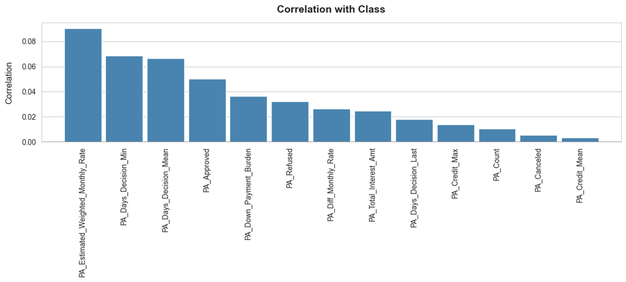

```python
df_pa = prev_appl_agg
df_pa = df_pa.merge(df[["Class", "SK_ID_CURR"]], on="SK_ID_CURR", how="left").drop(columns="SK_ID_CURR")

plot_feature_correlation(df_pa, [c for c in df_pa.columns])
```

Repayment behavior features were created from the original installments_payments.csv variables. These engineered features capture different aspects of installment payment performance, including the number of installments (IP_Count), worst observed delay (IP_Delay_Max), recent delay dynamics over the last months (IP_Delay_Trend_6_M), recent maximum delay (IP_Recent_Delay_Max), proportion of late payments (IP_Late_Payment_Rate), and payment-to-installment adequacy ratio (IP_Ratio_Min). These features aim to capture both historical and recent repayment behavior, which are key dimensions in assessing short-term and long-term credit risk. Summary statistics for repayment behavior at the customer level are presented below.

```python
instal_pay = pd.read_csv("installments_payments.csv").sort_values(["SK_ID_CURR", "DAYS_INSTALMENT"], na_position="last")
instal_pay["IP_Delay"] = np.maximum(instal_pay["DAYS_ENTRY_PAYMENT"] - instal_pay["DAYS_INSTALMENT"], 0)
instal_pay["IP_Late_Payment"] = ( instal_pay["IP_Delay"] > 0 ).astype(int)
instal_pay["IP_Ratio"] = instal_pay["AMT_PAYMENT"] / instal_pay["AMT_INSTALMENT"].replace(0, np.nan)
#instal_pay["IP_Zero_Installment"] = (instal_pay["AMT_INSTALMENT"] == 0).astype(int)
installments_agg = instal_pay.groupby("SK_ID_CURR").agg(
    IP_Count=("SK_ID_PREV", "count"),
    IP_Delay_Max=("IP_Delay", "max"),
    IP_Delay_Trend_6_M=("IP_Delay", lambda x: np.polyfit( np.arange(6), x.iloc[-6:].values, 1 )[0] if len(x) >= 6 else np.nan ),
    # IP_Delay_Last_6_Mean=("IP_Delay", lambda x: x.iloc[-6:].mean()),
    # IP_Delay_Previous_6_Mean=("IP_Delay", lambda x: x.iloc[-12:-6].mean()),
    # IP_Delay_Recent_Change=("IP_Delay", lambda x: x.iloc[-6:].mean() - x.iloc[-12:-6].mean()),
    IP_Recent_Delay_Max=("IP_Delay", lambda x: x.iloc[-6:].max()),
    # Delay_Mean=("INSTALMENT_PAY_DELAY", "mean"),
    IP_Late_Payment_Rate=("IP_Late_Payment", "mean"),
    IP_Ratio_Min=("IP_Ratio", "min")
    # IP_Zero_Installment_Count=("IP_Zero_Installment", "sum")
    # IP_Ratio_Median=("IP_Ratio", "median")
    # IP_Amt_Payment_Mean=("AMT_PAYMENT", "mean"),
    # IP_Amt_Installment_Mean=("AMT_INSTALMENT", "mean")
).reset_index()
del instal_pay
gc.collect()
installments_agg.describe()
```

|  | SK_ID_CURR | IP_Count | IP_Delay_Max | IP_Delay_Trend_6_M | IP_Recent_Delay_Max | IP_Late_Payment_Rate | IP_Ratio_Min |
| --- | --- | --- | --- | --- | --- | --- | --- |
| count | 339587.000000 | 339587.000000 | 339578.000000 | 320822.000000 | 339548.000000 | 339587.000000 | 339575.000000 |
| mean | 278154.892278 | 40.064552 | 17.844109 | 0.055808 | 3.604436 | 0.074385 | 0.597179 |
| std | 102880.492598 | 41.053343 | 108.275247 | 5.666200 | 50.142927 | 0.114490 | 0.471829 |
| min | 100001.000000 | 1.000000 | 0.000000 | -396.228571 | 0.000000 | 0.000000 | 0.000000 |
| 25% | 189042.500000 | 12.000000 | 0.000000 | 0.000000 | 0.000000 | 0.000000 | 0.015000 |
| 50% | 278238.000000 | 25.000000 | 1.000000 | 0.000000 | 0.000000 | 0.017857 | 1.000000 |
| 75% | 367315.500000 | 51.000000 | 9.000000 | 0.000000 | 0.000000 | 0.109375 | 1.000000 |
| max | 456255.000000 | 372.000000 | 2884.000000 | 386.800000 | 2882.000000 | 1.000000 | 1.969512 |

The following chart presents the phi-k correlation between the engineered installments payment features and the target variable (Class). The results indicate that IP_Late_Payment_Rate stands out as the feature most strongly associated with the target variable, compared to the remaining features in this subset. This suggests that the frequency of late payments is a key behavioral indicator of credit risk.

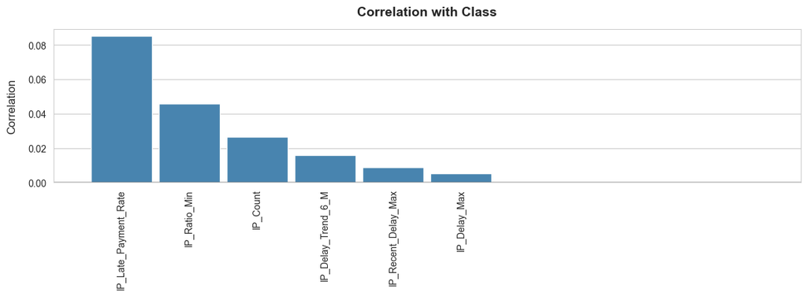

```python
df_instal = installments_agg
df_instal = df_instal.merge(df[["Class", "SK_ID_CURR"]], on="SK_ID_CURR", how="left").drop(columns="SK_ID_CURR")

plot_feature_correlation(df_instal, [c for c in df_instal.columns])
```

Historical cash loan behavior was summarized using a set of engineered features derived from the POS_CASH_balance.csv dataset. These features were aggregated at the customer level to capture patterns in past point-of-sale and cash loan repayment behavior. The resulting variables include POS_Loan_Count, POS_Remaining_Installments, POS_Worst_DPD, POS_DPD_Mean, POS_Ever_Late_Rate, and POS_DPD_Ratio, which describe loan volume, repayment progress, delinquency severity, and frequency of late payments. These features capture short-term repayment dynamics in revolving and installment-based cash credit products, complementing longer-term credit behavior captured in other datasets. Summary statistics for the engineered cash loan behavior features at customer level are presented below.

```python
pos_cash = pd.read_csv("POS_CASH_balance.csv")
pos_cash = pos_cash.sort_values(["SK_ID_CURR", "SK_ID_PREV"])
pos_cash["IS_DPD"] = (pos_cash["SK_DPD"] > 0).astype(int)
pos_cash_agg = pos_cash.groupby(["SK_ID_PREV", "SK_ID_CURR"]).agg(
    POS_Remaining_Installments_Min=("CNT_INSTALMENT_FUTURE", "min"),
    POS_DPD_Max=("SK_DPD", "max"),
    POS_DPD_Avg=("SK_DPD", "mean"),
    POS_Is_DPD_Mean=("IS_DPD", "mean"),
    POS_Ever_DPD=("IS_DPD", "max")
).reset_index()
pos_cash_agg = pos_cash_agg.groupby("SK_ID_CURR").agg(
    POS_Loan_Count=("SK_ID_PREV", "nunique"),
    POS_Remaining_Installments=("POS_Remaining_Installments_Min", "sum"),
    POS_Worst_DPD=("POS_DPD_Max", "max"),
    POS_DPD_Mean=("POS_DPD_Avg", "mean"),
    POS_Ever_Late_Rate=("POS_Ever_DPD", "mean"),
    POS_DPD_Ratio=("POS_Is_DPD_Mean", "mean")
).reset_index()
del pos_cash
gc.collect()
pos_cash_agg.describe()
```

|  | SK_ID_CURR | POS_Loan_Count | POS_Remaining_Installments | POS_Worst_DPD | POS_DPD_Mean | POS_Ever_Late_Rate | POS_DPD_Ratio |
| --- | --- | --- | --- | --- | --- | --- | --- |
| count | 337252.000000 | 337252.000000 | 337252.000000 | 337252.000000 | 337252.000000 | 337252.000000 | 337252.00000 |
| mean | 278163.132678 | 2.776336 | 6.032445 | 15.294106 | 2.861001 | 0.083588 | 0.01813 |
| std | 102877.889290 | 1.975222 | 11.693744 | 151.343806 | 43.107499 | 0.211854 | 0.06551 |
| min | 100001.000000 | 1.000000 | 0.000000 | 0.000000 | 0.000000 | 0.000000 | 0.00000 |
| 25% | 189046.750000 | 1.000000 | 0.000000 | 0.000000 | 0.000000 | 0.000000 | 0.00000 |
| 50% | 278241.500000 | 2.000000 | 0.000000 | 0.000000 | 0.000000 | 0.000000 | 0.00000 |
| 75% | 367320.250000 | 4.000000 | 7.000000 | 0.000000 | 0.000000 | 0.000000 | 0.00000 |
| max | 456255.000000 | 26.000000 | 132.000000 | 4231.000000 | 2298.542553 | 1.000000 | 1.00000 |

The following chart presents the phi-k correlation between the engineered point-of-sale cash features and the target variable (Class). The results indicate that POS_Ever_Late_Rate stands out as the feature most strongly associated with the target variable, compared to the remaining features in this subset. This suggests that the frequency of past late payments in point-of-sale and cash credit products is a key indicator of repayment risk. This reinforces the importance of short-term repayment behavior as a strong predictor of credit default risk.

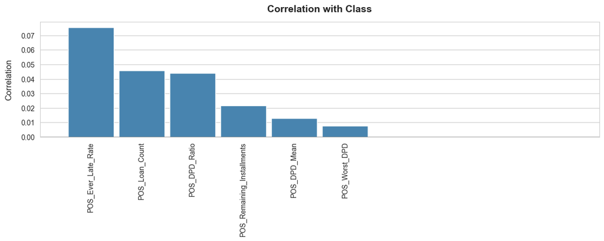

```python
df_pos = pos_cash_agg
df_pos = df_pos.merge(df[["Class", "SK_ID_CURR"]], on="SK_ID_CURR", how="left").drop(columns="SK_ID_CURR")

plot_feature_correlation(df_pos, [c for c in df_pos.columns])
```

Credit card utilization and payment behavior were summarized using a set of engineered features derived from the credit_card_balance.csv dataset. These features include CC_Utilization_Max, CC_Payment_Mean, CC_Drawings_Mean, and CC_Payment_Adequacy, capturing key aspects of credit card usage such as peak utilization, average repayment behavior, spending patterns, and payment sufficiency. These features capture short-term revolving credit behavior, which complements longer-term borrowing and repayment patterns observed in other datasets. Summary statistics for the engineered credit card behavior features at customer level are presented below.

```python
cc_bal = pd.read_csv("credit_card_balance.csv")
cc_bal = cc_bal.sort_values(["SK_ID_CURR", "SK_ID_PREV", "MONTHS_BALANCE"])
cc_bal["CC_Utilization"] = cc_bal["AMT_BALANCE"] / cc_bal["AMT_CREDIT_LIMIT_ACTUAL"].replace(0, np.nan)
cc_bal["CC_Payment_Adequacy"] = cc_bal["AMT_PAYMENT_CURRENT"] / cc_bal["AMT_DRAWINGS_CURRENT"].replace(0, np.nan)
cc_bal_agg = cc_bal.groupby(["SK_ID_PREV", "SK_ID_CURR"]).agg(
    CC_Utilization_Max=("CC_Utilization", "max"),
    CC_Payment_Mean=("AMT_PAYMENT_TOTAL_CURRENT", "mean"),
    CC_Drawings_Mean=("CNT_DRAWINGS_CURRENT", "mean"),
    CC_Payment_Adequacy=("CC_Payment_Adequacy", "mean"),
).reset_index()
cc_bal_agg = cc_bal_agg.groupby("SK_ID_CURR").agg(
    CC_Utilization_Max=("CC_Utilization_Max", "max"),
    CC_Payment_Mean=("CC_Payment_Mean", "mean"),
    CC_Drawings_Mean=("CC_Drawings_Mean", "mean"),
    CC_Payment_Adequacy=("CC_Payment_Adequacy", "mean"),
).reset_index()
del cc_bal
gc.collect()
cc_bal_agg.describe()
```

|  | SK_ID_CURR | CC_Utilization_Max | CC_Payment_Mean | CC_Drawings_Mean | CC_Payment_Adequacy |
| --- | --- | --- | --- | --- | --- |
| count | 103558.000000 | 102445.000000 | 1.035580e+05 | 103558.000000 | 68060.000000 |
| mean | 278381.457956 | 0.622298 | 1.028498e+04 | 1.518594 | 12.148532 |
| std | 102779.519683 | 0.482908 | 2.193770e+04 | 3.659505 | 1036.446305 |
| min | 100006.000000 | 0.000000 | 0.000000e+00 | 0.000000 | -4.132999 |
| 25% | 189536.250000 | 0.000000 | 0.000000e+00 | 0.000000 | 0.441647 |
| 50% | 278649.000000 | 0.939516 | 3.991429e+03 | 0.205479 | 1.010445 |
| 75% | 367690.000000 | 1.043610 | 1.190428e+04 | 1.300000 | 2.096731 |
| max | 456250.000000 | 11.777510 | 1.591837e+06 | 118.250000 | 203604.085366 |

The following chart presents the phi-k correlation between the engineered credit card balance features and the target variable (Class). The results indicate that CC_Drawings_Mean stands out as the feature most strongly associated with the target variable, compared to the remaining features in this subset. Although CC_Payment_Adequacy shows negligible phi-k correlation with the target variable when analyzed in isolation, it still contributes positively to model performance according to feature importance from the LightGBM model. This suggests that its predictive value may arise through non-linear interactions with other variables rather than through a direct marginal relationship with the target. This highlights the limitation of univariate association measures for capturing predictive value in non-linear models.

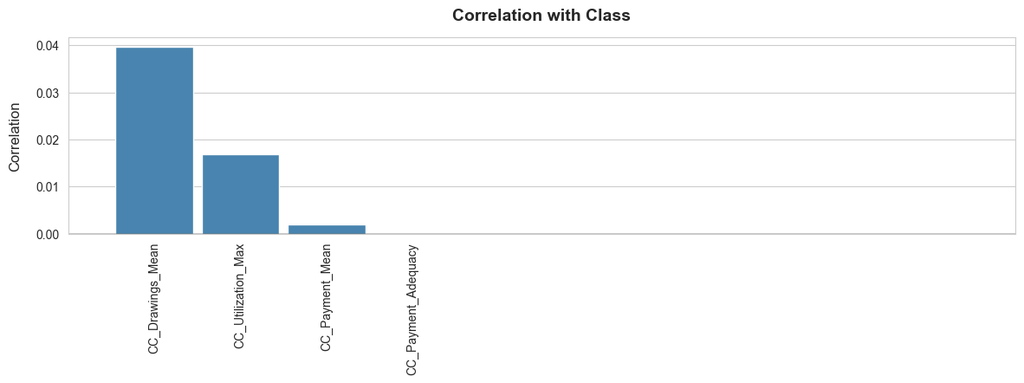

```python
df_cc = cc_bal_agg
df_cc = df_cc.merge(df[["Class", "SK_ID_CURR"]], on="SK_ID_CURR", how="left").drop(columns="SK_ID_CURR")

plot_feature_correlation(df_cc, [c for c in df_cc.columns])
```

In the next step, all previously engineered feature subsets were merged into the main application dataset. Subsequently, three additional features were created: (1) the product of credit amount and the estimated weighted monthly rate of the previous loan, used as a proxy for overall credit burden; (2) the product of the annuity-to-income ratio and the estimated weighted monthly rate of the previous loan, used as an approximation of monthly financial pressure; and (3) the total number of missing values per row, capturing overall data completeness as a potential signal of risk. These engineered features contributed to improved predictive performance and were retained in the final modeling dataset. The inclusion of missing-value counts also reflects the hypothesis that data completeness itself may carry information about applicant behavior or data quality patterns correlated with risk.

```python
df = df.merge( bureau_by_customer, on="SK_ID_CURR", how="left" )
df = df.merge( prev_appl_agg, on="SK_ID_CURR", how="left" )
df = df.merge( installments_agg, on="SK_ID_CURR", how="left" )
df = df.merge( pos_cash_agg, on="SK_ID_CURR", how="left" )
df = df.merge( cc_bal_agg, on="SK_ID_CURR", how="left" )
df["Credit_x_Rate"] = df["AMT_CREDIT"] * df["PA_Estimated_Weighted_Monthly_Rate"]
df["Annuity_Income_Ratio_Est_Rate"] = df["Annuity_Income_Ratio"] * df["PA_Estimated_Weighted_Monthly_Rate"]
df["Missing_Per_Row"] = df.isnull().sum(axis=1)
```

As noted at the start of this study, the EXT_SOURCE variables are among the most important, and a large proportion of their values are missing, specifically the EXT_SOURCE_1 variable. Next, the possibility of reconstructing the missing values with low error for these variables will be assessed using a LightGBM regressor trained with non-missing observations of each corresponding variable.

The following table shows a high R-squared for EXT_SOURCE_1 of approximately 0.89 and a mean absolute error of 0.042, indicating that the variable can be reconstructed with low error. An R² of 0.89 means the score is largely explainable by variables already present in the dataset. Therefore, replacing missing values with model-based estimates is less likely to inject noise than simple mean or median imputation. The error for the other external source variables is meaningful and therefore their missing values won't be reconstructed.

```python
def test_features_missing_values_reconstruction():
    targets = ["EXT_SOURCE_1", "EXT_SOURCE_2", "EXT_SOURCE_3"]
    results = []
    for col in targets:
        train_reg = df[df[col].notna()].copy()
        X_reg = train_reg.drop( columns=[ col, "Class", "SK_ID_CURR" ], errors="ignore" )
        y_reg = train_reg[col]
        X_reg = X_reg.select_dtypes(include="number")
        X_train_reg, X_valid_reg, y_train_reg, y_valid_reg = train_test_split(X_reg, y_reg, test_size=0.2, random_state=42 )
        reg = LGBMRegressor( n_estimators=300, random_state=42, verbosity=-1 )
        reg.fit(X_train_reg, y_train_reg)
        pred = reg.predict(X_valid_reg)
        results.append({"Feature": col, "R²": r2_score(y_valid_reg, pred), "MAE": mean_absolute_error(y_valid_reg, pred)})
    return pd.DataFrame(results).style.hide(axis="index")
test_features_missing_values_reconstruction()
```

| Feature | R² | MAE |
| --- | --- | --- |
| EXT_SOURCE_1 | 0.886662 | 0.041728 |
| EXT_SOURCE_2 | 0.486803 | 0.095053 |
| EXT_SOURCE_3 | 0.560798 | 0.085494 |

In the next step, missing values in EXT_SOURCE_1 were reconstructed using a LightGBM regressor trained on the available non-missing observations of the variable, using the remaining features as predictors. This approach was motivated by the high predictive accuracy observed in the reconstruction task (R² ≈ 0.89, MAE ≈ 0.042), suggesting that a substantial portion of the variability in EXT_SOURCE_1 can be explained by existing dataset features. Following imputation, the derived feature Ext_Source_Weighted was removed to avoid redundancy, the Missing_Per_Row feature was recalculated to reflect updated data completeness, and the indicator variable Ext_Source_1_Missing was retained to preserve information about originally missing values. Summary statistics for the final processed dataset are presented below.

```python
target = "EXT_SOURCE_1"
train_reg = df[df[target].notna()].copy()
X_reg = train_reg.drop( columns=[ target, "Class" ], errors="ignore" )
y_reg = train_reg[target]
reg = LGBMRegressor( n_estimators=300, random_state=42, verbosity=-1 )
reg.fit(X_reg, y_reg)
missing_mask = df[target].isna()
X_missing = ( df.loc[missing_mask].drop(columns=[ target, "Class" ], errors="ignore").select_dtypes(include="number") )
df.loc[missing_mask, target] = reg.predict(X_missing)
df = df.drop(columns="Ext_Source_Weighted")
df["Missing_Per_Row"] = df.isnull().sum(axis=1)
df.describe()
```

|  | SK_ID_CURR | Class | AMT_INCOME_TOTAL | AMT_CREDIT | AMT_ANNUITY | AMT_GOODS_PRICE | REGION_POPULATION_RELATIVE | DAYS_BIRTH | DAYS_EMPLOYED | DAYS_REGISTRATION | DAYS_ID_PUBLISH | OWN_CAR_AGE | FLAG_EMP_PHONE | FLAG_WORK_PHONE | FLAG_EMAIL | CNT_FAM_MEMBERS | REGION_RATING_CLIENT | REGION_RATING_CLIENT_W_CITY | HOUR_APPR_PROCESS_START | REG_CITY_NOT_LIVE_CITY | REG_CITY_NOT_WORK_CITY | LIVE_CITY_NOT_WORK_CITY | EXT_SOURCE_1 | EXT_SOURCE_2 | EXT_SOURCE_3 | ELEVATORS_AVG | FLOORSMAX_AVG | FLOORSMIN_AVG | FLOORSMAX_MODE | … |
| --- | --- | --- | --- | --- | --- | --- | --- | --- | --- | --- | --- | --- | --- | --- | --- | --- | --- | --- | --- | --- | --- | --- | --- | --- | --- | --- | --- | --- | --- | --- |
| count | 307511.000000 | 307511.000000 | 3.075110e+05 | 3.075110e+05 | 307499.000000 | 3.072330e+05 | 307511.000000 | 307511.000000 | 252137.000000 | 307511.000000 | 307511.000000 | 104582.000000 | 307511.000000 | 307511.000000 | 307511.000000 | 307509.000000 | 307511.000000 | 307511.000000 | 307511.000000 | 307511.000000 | 307511.000000 | 307511.000000 | 307511.000000 | 3.068510e+05 | 246546.000000 | 143620.000000 | 154491.000000 | 98869.000000 | 154491.000000 | … |
| mean | 278180.518577 | 0.080729 | 1.687979e+05 | 5.990260e+05 | 27108.573909 | 5.383962e+05 | 0.020868 | -16036.995067 | -2384.169325 | -4986.120328 | -2994.202373 | 12.061091 | 0.819889 | 0.199368 | 0.056720 | 2.152665 | 2.052463 | 2.031521 | 12.063419 | 0.078173 | 0.230454 | 0.179555 | 0.506428 | 5.143927e-01 | 0.510853 | 0.078942 | 0.226282 | 0.231894 | 0.222315 | … |
| std | 102790.175348 | 0.272419 | 2.371231e+05 | 4.024908e+05 | 14493.737315 | 3.694465e+05 | 0.013831 | 4363.988632 | 2338.360162 | 3522.886321 | 1509.450419 | 11.944812 | 0.384280 | 0.399526 | 0.231307 | 0.910682 | 0.509034 | 0.502737 | 3.265832 | 0.268444 | 0.421124 | 0.383817 | 0.194979 | 1.910602e-01 | 0.194844 | 0.134576 | 0.144641 | 0.161380 | 0.143709 | … |
| min | 100002.000000 | 0.000000 | 2.565000e+04 | 4.500000e+04 | 1615.500000 | 4.050000e+04 | 0.000290 | -25229.000000 | -17912.000000 | -24672.000000 | -7197.000000 | 0.000000 | 0.000000 | 0.000000 | 0.000000 | 1.000000 | 1.000000 | 1.000000 | 0.000000 | 0.000000 | 0.000000 | 0.000000 | 0.012379 | 8.173617e-08 | 0.000527 | 0.000000 | 0.000000 | 0.000000 | 0.000000 | … |
| 25% | 189145.500000 | 0.000000 | 1.125000e+05 | 2.700000e+05 | 16524.000000 | 2.385000e+05 | 0.010006 | -19682.000000 | -3175.000000 | -7479.500000 | -4299.000000 | 5.000000 | 1.000000 | 0.000000 | 0.000000 | 2.000000 | 2.000000 | 2.000000 | 10.000000 | 0.000000 | 0.000000 | 0.000000 | 0.356374 | 3.924574e-01 | 0.370650 | 0.000000 | 0.166700 | 0.083300 | 0.166700 | … |
| 50% | 278202.000000 | 0.000000 | 1.471500e+05 | 5.135310e+05 | 24903.000000 | 4.500000e+05 | 0.018850 | -15750.000000 | -1648.000000 | -4504.000000 | -3254.000000 | 9.000000 | 1.000000 | 0.000000 | 0.000000 | 2.000000 | 2.000000 | 2.000000 | 12.000000 | 0.000000 | 0.000000 | 0.000000 | 0.502737 | 5.659614e-01 | 0.535276 | 0.000000 | 0.166700 | 0.208300 | 0.166700 | … |
| 75% | 367142.500000 | 0.000000 | 2.025000e+05 | 8.086500e+05 | 34596.000000 | 6.795000e+05 | 0.028663 | -12413.000000 | -767.000000 | -2010.000000 | -1720.000000 | 15.000000 | 1.000000 | 0.000000 | 0.000000 | 3.000000 | 2.000000 | 2.000000 | 14.000000 | 0.000000 | 0.000000 | 0.000000 | 0.665393 | 6.636171e-01 | 0.669057 | 0.120000 | 0.333300 | 0.375000 | 0.333300 | … |
| max | 456255.000000 | 1.000000 | 1.170000e+08 | 4.050000e+06 | 258025.500000 | 4.050000e+06 | 0.072508 | -7489.000000 | 0.000000 | 0.000000 | 0.000000 | 91.000000 | 1.000000 | 1.000000 | 1.000000 | 20.000000 | 3.000000 | 3.000000 | 23.000000 | 1.000000 | 1.000000 | 1.000000 | 1.028116 | 8.549997e-01 | 0.896010 | 1.000000 | 1.000000 | 1.000000 | 1.000000 | … |

# Model Training

In the next step, the dataset was split into training and testing sets. The final modeling dataset consisted of 101 independent variables, excluding SK_ID_CURR. A stratified split was applied, allocating 67% of the data for training and 33% for testing. Only the LightGBM algorithm was used for model training, due to its strong performance on tabular data, ability to handle missing values natively, and capacity to capture non-linear relationships and feature interactions. Experiments with XGBoost were also conducted; however, training under the same hyperparameter settings and feature dimensionality as the LightGBM model was not computationally feasible within the available hardware constraints. As a result, XGBoost was not included in the final model selection process, and LightGBM was retained as the primary algorithm due to its computational efficiency in the context of this study.

```python
models = dict()
X = df.select_dtypes(include='number').drop(columns=["Class", "SK_ID_CURR"], axis=1)
Y = df["Class"]
X_train, X_test, Y_train, Y_test = train_test_split(X, Y, test_size=0.33, random_state=42, stratify=Y)

print('X_train.shape=', X_train.shape, 'Y_train.shape=', Y_train.shape)
print('X_test.shape=', X_test.shape, 'Y_test.shape=', Y_test.shape)
```

[output not shown]

Hyperparameter optimization was performed using RandomizedSearchCV with Stratified K-Fold cross-validation. The final optimization focused on maximizing ROC-AUC, prioritizing the model's ability to rank applicants by default risk rather than optimizing probability calibration or threshold-dependent classification metrics.

```python
def run_light_gbm():
    scale_pos_weight = len(Y_train[Y_train.eq(0)]) / len(Y_train[Y_train.eq(1)])

    parameters = {
        "n_estimators": [300, 400],
        "max_depth": [-1], # -1 = sem restrições  -  para fins de inspeção, em caso de suspeita de overfitting, aumentar para 5 para limitar
        "num_leaves": [31, 63, 127],# para fins de inspeção, em caso de suspeita de overfitting, reduzir para 15
        "learning_rate": [0.01, 0.02, 0.05],
        "subsample": [0.8, 0.9],
        "colsample_bytree": [0.8, 0.9],
        "scale_pos_weight": [scale_pos_weight*0.5, scale_pos_weight, scale_pos_weight*1.5]
    }

    lgbm = LGBMClassifier( random_state=42, n_jobs=-1 )  #LGBMClassifier(**cv.best_params_)

    cv = RandomizedSearchCV(
        estimator=lgbm,
        param_distributions=parameters,
        n_iter=20,
        scoring={"roc_auc": "roc_auc"},
        refit="roc_auc",
        cv=StratifiedKFold(n_splits=3, shuffle=True, random_state=42),
        verbose=1,
        random_state=42,
        n_jobs=-1
    )

    cv.fit(X_train, Y_train)

    best_model = cv.best_estimator_

    proba = best_model.predict_proba(X_test)[:, 1]

    results = []
    logloss = log_loss(Y_test, proba)
    brier = brier_score_loss(Y_test, proba)
    baseline_brier = brier_score_loss(Y_test, np.full_like(Y_test, Y_test.mean(), dtype=float))
    brier_skill_score = 100 * (baseline_brier - brier) / baseline_brier
    roc = roc_auc_score(Y_test, proba)
    pr = average_precision_score(Y_test, proba)
    for t in np.linspace(0.0, 1.0, 101):
        y_pred = (proba >= t)
        cm = confusion_matrix(Y_test, y_pred)
        results.append({
            "Threshold": t,
            "PrecisionScore": precision_score(Y_test, y_pred, zero_division=0),
            "RecallScore": recall_score(Y_test, y_pred, zero_division=0),
            "F1Score": f1_score(Y_test, y_pred, zero_division=0),
            "TP": cm[1, 1],
            "TN": cm[0, 0],
            "FP": cm[0, 1],
            "FN": cm[1, 0],
            "MCC": matthews_corrcoef(Y_test, y_pred),
            "LogLoss": logloss,
            "BrierScore": brier,
            "BL_Brier": baseline_brier,
            "BSS": brier_skill_score,
            "ROC_AUC": roc,
            "PR_AUC": pr
        })
    df_metrics = pd.DataFrame(results)
    df_cv_results = pd.DataFrame(cv.cv_results_)
    df_importances = pd.DataFrame({
        "Feature": X.columns,
        "Importance": best_model.booster_.feature_importance(importance_type="gain")
    })
    df_importances = df_importances.sort_values("Importance", ascending=False).round().reset_index(drop=True).transpose()

    return { "metrics": df_metrics, "best_params": cv.best_params_, "best_model": best_model, "importances": df_importances, "cv_results": df_cv_results, "y_pred": y_pred, "y_proba": proba }

light_gbm = run_light_gbm()
models.update({"LightGBM": light_gbm})
```

The best hyperparameter configuration selected through randomized search with stratified cross-validation is presented below.

```python
df_params = pd.DataFrame.from_dict(light_gbm["best_params"], orient="index")
df_params.columns = ["Value"]
df_params.round(2)
```

|  | Value |
| --- | --- |
| subsample | 0.90 |
| scale_pos_weight | 5.69 |
| num_leaves | 31.00 |
| n_estimators | 300.00 |
| max_depth | -1.00 |
| learning_rate | 0.05 |
| colsample_bytree | 0.80 |

# Model Evaluation

Class weighting improved the model’s ability to discriminate between default and non-default cases, as reflected by the ROC-AUC and PR-AUC scores. However, this came at the cost of poorer probability calibration, as indicated by the Brier score and log loss shown in the following metrics table. This trade-off is expected in cost-sensitive learning settings, where class weighting prioritizes minority class detection over probability calibration.

The Brier Skill Score (BSS) was computed to assess probabilistic calibration relative to a naive baseline model that always predicts the empirical default rate. Positive values of BSS indicate improvement over the baseline, while negative values indicate worse calibration performance.

The ROC-AUC of approximately 0.78 indicates good overall separability between default and non-default classes. Given the strong class imbalance in the dataset (positive class prevalence ≈ 0.08), PR-AUC provides a more informative measure of performance on the minority class. The model achieved a PR-AUC of approximately 0.27, which corresponds to a more than threefold improvement over the random baseline (approximately equal to class prevalence), demonstrating a substantial lift in identifying default cases compared to a non-informative classifier.

```python
light_gbm["metrics"].iloc[45:50].style.hide(axis="index")
```

| Threshold | PrecisionScore | RecallScore | F1Score | TP | TN | FP | FN | MCC | LogLoss | BrierScore | BL_Brier | BSS | ROC_AUC | PR_AUC |
| --- | --- | --- | --- | --- | --- | --- | --- | --- | --- | --- | --- | --- | --- | --- |
| 0.450000 | 0.238420 | 0.524658 | 0.327854 | 4298 | 79558 | 13729 | 3894 | 0.269048 | 0.368276 | 0.111412 | 0.074209 | -50.132380 | 0.782507 | 0.273051 |
| 0.460000 | 0.243041 | 0.508423 | 0.328872 | 4165 | 80315 | 12972 | 4027 | 0.268581 | 0.368276 | 0.111412 | 0.074209 | -50.132380 | 0.782507 | 0.273051 |
| 0.470000 | 0.247570 | 0.491211 | 0.329215 | 4024 | 81057 | 12230 | 4168 | 0.267471 | 0.368276 | 0.111412 | 0.074209 | -50.132380 | 0.782507 | 0.273051 |
| 0.480000 | 0.252853 | 0.475952 | 0.330256 | 3899 | 81766 | 11521 | 4293 | 0.267464 | 0.368276 | 0.111412 | 0.074209 | -50.132380 | 0.782507 | 0.273051 |
| 0.490000 | 0.258102 | 0.460815 | 0.330879 | 3775 | 82436 | 10851 | 4417 | 0.267200 | 0.368276 | 0.111412 | 0.074209 | -50.132380 | 0.782507 | 0.273051 |

Although the model achieves a PR-AUC of approximately 0.27, representing a substantial improvement over the baseline prevalence of ~0.08, the absolute precision levels remain relatively low at moderate recall values. For example, precision is approximately 0.24 when recall is around 0.5, indicating a significant number of false positives when attempting to capture a large proportion of default cases.

This reflects the inherent difficulty of the problem, where default and non-default classes exhibit substantial overlap in feature space. As a result, the model is more suitable for ranking applicants by relative risk rather than producing highly precise binary classifications. The following chart presents the Precision–Recall curve (PR curve) and the Receiver Operating Characteristic curve (ROC curve).

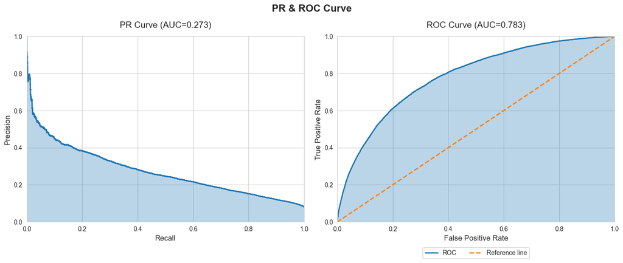

```python
def model_pr_and_roc_curve():
    fig, axes = plt.subplots(1, 2, figsize=(14, 6))
    precision, recall, _ = precision_recall_curve(Y_test, light_gbm["y_proba"])
    pr_auc = average_precision_score(Y_test, light_gbm["y_proba"])
    axes[0].plot(recall, precision, linewidth=2)
    axes[0].fill_between( recall, precision, alpha=0.3 )
    axes[0].set_title(f"PR Curve (AUC={pr_auc:.3f})", fontsize=14, pad=14)
    axes[0].set_xlabel("Recall", fontsize=12)
    axes[0].set_ylabel("Precision", fontsize=12)
    axes[0].set_xlim(0, 1)
    axes[0].set_ylim(0, 1)

    fpr, tpr, _ = roc_curve(Y_test, light_gbm["y_proba"])
    roc_auc = roc_auc_score(Y_test, light_gbm["y_proba"])
    axes[1].plot(fpr, tpr, linewidth=2, label="ROC")
    axes[1].plot([0, 1], [0, 1], linestyle='--', linewidth=2, label="Reference line")
    axes[1].fill_between( fpr, tpr, alpha=0.3 )
    axes[1].set_title(f"ROC Curve (AUC={roc_auc:.3f})", fontsize=14, pad=14)
    axes[1].set_xlabel("False Positive Rate", fontsize=12)
    axes[1].set_ylabel("True Positive Rate", fontsize=12)
    axes[1].set_xlim(0, 1)
    axes[1].set_ylim(0, 1)
    axes[1].legend(loc="upper center", bbox_to_anchor=(0.5, -0.12), ncol=2)

    plt.suptitle(f"PR & ROC Curve", y=0.98, fontsize=16, fontweight="bold")
    plt.tight_layout()
    plt.show()

model_pr_and_roc_curve()
```

The following table presents feature importances derived from the LightGBM model. External source variables represent the most influential predictors, consistently ranking at the top of the importance distribution. This is broadly aligned with the phi-k association analysis, which also highlights these features as having the strongest bivariate relationship with the target variable. This is expected, as these variables represent pre-computed risk scores derived from external credit bureaus and third-party data providers. Unlike internal application features, which are self-reported or derived from transactional summaries, external scores incorporate broader historical and behavioral information that is not directly observable in the dataset. As a result, they capture latent risk factors that are difficult to reconstruct through feature engineering alone, making them highly predictive of default behavior. This explains their consistently high importance in both the LightGBM model and the phi-k correlation analysis.

The dominance of external source variables also suggests that the predictive signal in the remaining engineered features is more fragmented and distributed across multiple variables, rather than concentrated in a few highly informative predictors. Nonetheless, several engineered features related to credit burden and financial stress also show strong importance in the LightGBM model and contribute meaningfully to predictive performance. In particular, variables capturing credit and payment behavior, as well as ratios reflecting financial pressure (such as credit-to-income and debt-to-income proxies), play an important role in modeling default risk. These features provide insight into the applicant’s repayment capacity and leverage, which are key drivers of credit risk. Additionally, demographic and employment-related variables such as age (DAYS_BIRTH), employment duration (DAYS_EMPLOYED), and occupation type remain relevant predictors, reflecting the influence of socioeconomic stability on default probability.

```python
def show_importances_split_by_columns(data):
    importances = data.T
    n = 10
    sections = []
    for i in range(0, len(importances), n):
        section = importances.iloc[i:i+n].reset_index(drop=True)
        section[section.columns[1]] = section[section.columns[1]].astype("Int32")
        section.columns = [f"Feature_{i+1}_{i+10}", f"Importance_{i+1}_{i+10}"]
        sections.append(section)
    return pd.concat(sections, axis=1).style.hide(axis="index")

show_importances_split_by_columns(light_gbm["importances"])
```

| Feature_1_10 | Importance_1_10 | Feature_11_20 | Importance_11_20 | Feature_21_30 | Importance_21_30 | Feature_31_40 | Importance_31_40 | Feature_41_50 | Importance_41_50 | Feature_51_60 | Importance_51_60 | Feature_61_70 | Importance_61_70 | Feature_71_80 | Importance_71_80 | Feature_81_90 | Importance_81_90 | Feature_91_100 | Importance_91_100 | Feature_101_110 | Importance_101_110 |
| --- | --- | --- | --- | --- | --- | --- | --- | --- | --- | --- | --- | --- | --- | --- | --- | --- | --- | --- | --- | --- | --- |
| EXT_SOURCE_3 | 199481 | CC_Utilization_Max | 17585 | IP_Count | 10484 | PA_Credit_Max | 7601 | Income_Per_Fam_Member | 4959 | FLAG_DOCUMENT_3 | 3288 | POS_Ever_Late_Rate | 2123 | PA_Count | 1245 | FLOORSMIN_MODE | 682 | Commercial associate | 244 | Maternity leave | 0 |
| EXT_SOURCE_2 | 161827 | Annuity_Income_Ratio_Est_Rate | 15601 | AMT_GOODS_PRICE | 10112 | Is_Female | 7590 | Occupation | 4958 | BB_Months_Outstanding | 3217 | CNT_FAM_MEMBERS | 2073 | BB_DPD_Max | 1216 | FLOORSMAX_MEDI | 675 | FLOORSMIN_MEDI | 242 | nan |  |
| EXT_SOURCE_1 | 56799 | DAYS_BIRTH | 15459 | DAYS_ID_PUBLISH | 9968 | PA_Diff_Monthly_Rate | 7357 | Annuity_Income_Ratio | 4937 | B_Amt_Credit_Sum_Overdue | 3075 | CC_Payment_Mean | 1924 | POS_DPD_Mean | 1190 | Working | 587 | PA_Canceled | 123 | nan |  |
| Loan_Term_Estimate | 41561 | PA_Estimated_Weighted_Monthly_Rate | 14610 | PA_Days_Decision_Min | 9750 | DAYS_LAST_PHONE_CHANGE | 7052 | PA_Refused | 4782 | AMT_INCOME_TOTAL | 2906 | PA_Approved | 1870 | Cash loans | 1069 | POS_DPD_Ratio | 586 | REG_CITY_NOT_WORK_CITY | 112 | nan |  |
| IP_Recent_Delay_Max | 30834 | OWN_CAR_AGE | 14198 | Credit_x_Rate | 9691 | DAYS_REGISTRATION | 6629 | Goods_Price_Per_Income_Ratio | 4662 | FLOORSMAX_AVG | 2839 | REG_CITY_NOT_LIVE_CITY | 1773 | State servant | 1028 | FLOORSMAX_MODE | 559 | LIVE_CITY_NOT_WORK_CITY | 67 | nan |  |
| DAYS_EMPLOYED | 28710 | IP_Late_Payment_Rate | 12702 | Ext_Source_1_Missing | 9156 | PA_Credit_Mean | 6472 | Is_Male | 4399 | IP_Ratio_Min | 2656 | HOUR_APPR_PROCESS_START | 1726 | OBS_30_CNT_SOCIAL_CIRCLE | 1026 | B_Cnt_Credit_Prolong | 447 | FLAG_EMP_PHONE | 0 | nan |  |
| Credit_Goods_Ratio | 26311 | AMT_ANNUITY | 12063 | PA_Days_Decision_Mean | 9135 | REGION_POPULATION_RELATIVE | 5992 | Credit_Income_Ratio | 3860 | DEF_30_CNT_SOCIAL_CIRCLE | 2538 | BB_DPD_6_M_Ratio | 1600 | AMT_REQ_CREDIT_BUREAU_MON | 911 | REGION_RATING_CLIENT | 421 | Pensioner | 0 | nan |  |
| PA_Total_Interest_Amt | 25003 | Higher_Education | 11677 | PA_Down_Payment_Burden | 8212 | IP_Delay_Max | 5762 | REGION_RATING_CLIENT_W_CITY | 3801 | AMT_REQ_CREDIT_BUREAU_YEAR | 2458 | ELEVATORS_AVG | 1598 | OBS_60_CNT_SOCIAL_CIRCLE | 866 | Revolving loans | 359 | Businessman | 0 | nan |  |
| POS_Remaining_Installments | 17964 | Employed_To_Birth_Ratio | 10793 | Total_Area_Mode | 8167 | PA_Days_Decision_Last | 5530 | CC_Payment_Adequacy | 3564 | Missing_Per_Row | 2431 | FLAG_WORK_PHONE | 1519 | POS_Worst_DPD | 781 | Contact_Availability_Score | 340 | Unemployed | 0 | nan |  |
| CC_Drawings_Mean | 17789 | POS_Loan_Count | 10786 | AMT_CREDIT | 7919 | IP_Delay_Trend_6_M | 5216 | Living_Nonliving_Area_Ratio | 3466 | DEF_60_CNT_SOCIAL_CIRCLE | 2330 | FLOORSMIN_AVG | 1389 | Docs_Ratio | 725 | FLAG_EMAIL | 324 | Student | 0 | nan |  |

Overall, the model relies on a combination of external credit history signals and internally engineered financial stress indicators, complemented by demographic variables that capture long-term socioeconomic stability. The following chart presents the top 20 features ranked by LightGBM feature importance.

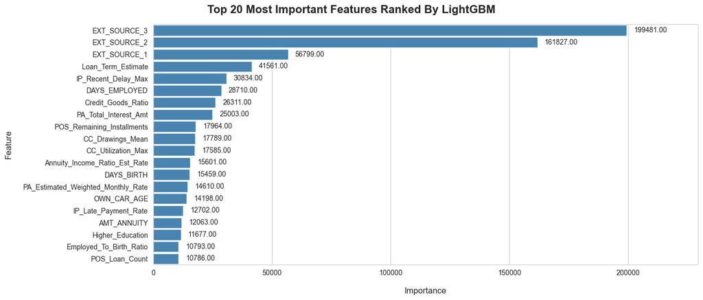

```python
def plot_top_20_most_important_features(data):
    sns.set_style("whitegrid")
    data = (data.T).head(20)
    fig, ax = plt.subplots(figsize=(14, 6))
    fig.suptitle( "Top 20 Most Important Features Ranked By LightGBM", y=0.98, fontsize=16, fontweight="bold" )

    df_melt = data.melt(
        id_vars=["Feature"],
        value_vars=["Importance"]
    )
    sns.barplot(
        data=df_melt,
        x="value",
        y="Feature",
        ax=ax,
        color=sns.color_palette("Blues", n_colors=5)[3],
        width=0.9
    )
    for container in ax.containers:
        ax.bar_label(
            container,
            fmt="%.2f",
            padding=10,
            fontsize=10
            #fontweight="bold"
        )
    ax.set_ylabel("Feature", fontsize=12, labelpad=15)
    ax.set_xlabel("Importance", fontsize=12, labelpad=15)
    ax.set_xlim(0, df_melt["value"].max() * 1.15)

    plt.tight_layout()
    plt.show()

plot_top_20_most_important_features(light_gbm["importances"])
```

The following chart shows feature importance aggregated by feature group. The application_train group dominates overall importance, largely due to the presence of external source variables, which are the strongest individual predictors in the model. This is followed by engineered features from previous_application and installments_payments, confirming that historical credit behavior provides complementary predictive information beyond the primary application data.

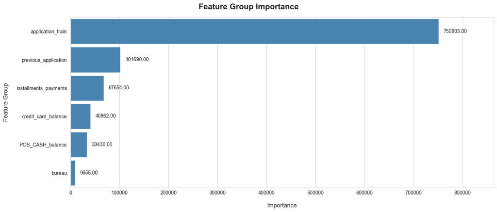

```python
def most_important_data_groups(data):
    feature_importance = data.T
    features_not_from_application_train = set(bureau_by_customer.columns) | set(prev_appl_agg.columns) | set(installments_agg.columns) | set(pos_cash_agg.columns) | set(cc_bal_agg.columns)
    dfs_dict = {
        "application_train": df[[c for c in df.columns if c not in ["SK_ID_CURR", *features_not_from_application_train]]],
        "bureau": bureau_by_customer[[c for c in bureau_by_customer.columns if "SK_ID_CURR" not in c]],
        "previous_application": prev_appl_agg[[c for c in prev_appl_agg.columns if "SK_ID_CURR" not in c]],
        "installments_payments": installments_agg[[c for c in installments_agg.columns if "SK_ID_CURR" not in c]],
        "POS_CASH_balance": pos_cash_agg[[c for c in pos_cash_agg.columns if "SK_ID_CURR" not in c]],
        "credit_card_balance": cc_bal_agg[[c for c in cc_bal_agg.columns if "SK_ID_CURR" not in c]]
    }

    feature_to_group = {}

    for group, df_group in dfs_dict.items():
        for col in df_group.columns:
            feature_to_group[col] = group
    feature_importance["Group"] = ( feature_importance["Feature"].map(feature_to_group) )

    feature_importance = feature_importance.groupby("Group").agg(
        Importance=("Importance", "sum")
    ).sort_values("Importance", ascending=False).reset_index()

    return feature_importance

def plot_feature_group_importance(data):
    data = most_important_data_groups(light_gbm["importances"])
    fig, ax = plt.subplots(figsize=(14, 6))
    fig.suptitle( "Feature Group Importance", y=0.98, fontsize=16, fontweight="bold" )

    df_melt = data.melt(
        id_vars=["Group"],
        value_vars=["Importance"]
    )

    sns.barplot(
        data=df_melt,
        x="value",
        y="Group",
        color=sns.color_palette("Blues", n_colors=5)[3],
        width=0.9,
        ax=ax
    )
    for container in ax.containers:
        ax.bar_label(
            container,
            fmt="%.2f",
            padding=10,
            fontsize=10
            #fontweight="bold"
        )
    ax.set_ylabel("Feature Group", fontsize=12, labelpad=15)
    ax.set_xlabel("Importance", fontsize=12, labelpad=15)
    ax.set_xlim(0, df_melt["value"].max() * 1.15)

    plt.tight_layout()
    plt.show()

plot_feature_group_importance(light_gbm["importances"])
```

```python
def plot_box_subplots():
    corr = df.corr(numeric_only=True)["Class"].drop("Class").abs().sort_values(ascending=False)
    features = corr.index
    n_features = len(features)
    cols = 4
    rows = int(np.ceil(n_features / cols))
    fig, axes = plt.subplots(rows, cols, figsize=(15, rows * 2.5))

    axes = axes.flatten()
    df1 = df.copy()

    for i, col in enumerate(features):
        df1.boxplot(column=col, by="Class", ax=axes[i], grid=False, boxprops=dict(facecolor="#3182bd", color="#3182bd"), medianprops=dict(color="Red", linewidth=2), patch_artist=True)
        axes[i].set_title(col, fontsize=13)
        axes[i].set_xlabel("")

    for j in range(len(features), len(axes)):
        fig.delaxes(axes[j])

    plt.suptitle("Feature Distribution by Class", y=1.001, fontsize=16, fontweight="bold")
    plt.tight_layout()
    plt.show()

plot_box_subplots()
```

[output not shown]

Final model performance:

- ROC-AUC: approximately 0.7825
- Stratified train/test split was used to preserve class distribution
- Cross-validation was applied during hyperparameter optimization
- Increasing the number of cross-validation folds from 3 to 5 did not result in measurable performance improvements under the chosen evaluation metric (ROC-AUC)

Feature ablation experiments indicated that even features with low individual importance can provide marginal predictive gain when combined within the model. Specifically:

- Features derived from previous_application contributed the most to overall predictive performance.
- Features from installments_payments, POS_CASH_balance, and credit_card_balance provided consistent additional predictive value.
- Bureau-derived features contributed smaller but still measurable improvements in model performance.

Overall, the results indicate that credit risk prediction benefits from combining multiple sources of information on past credit behavior, with each data group contributing incremental predictive signal.

# SHAP Analysis

The SHAP summary plot below was used to interpret feature contributions to model predictions at a local and global level. External source variables are the most influential features and show a clear monotonic relationship with the predicted probability of default: lower values of these variables are associated with higher risk, while higher values correspond to lower risk. The top 20 features also exhibit partially monotonic behavior, suggesting that for several variables there is a consistent directional relationship between feature value and default risk. In contrast, Loan_Term_Estimate shows a non-monotonic pattern, where both low and high values can contribute to increased or decreased predicted risk depending on the interaction with other variables. Despite this behavior, it remains one of the most important features, indicating strong interaction effects and non-linear relationships captured by the model.

Beyond external sources, SHAP analysis confirms that features related to credit burden and financial stress are also highly influential. This is consistent with the feature importance ranking obtained from the LightGBM model, reinforcing the robustness of these feature groups across different interpretability methods.

Overall, SHAP analysis confirms that the model relies primarily on external credit signals, complemented by engineered financial stress indicators and past credit behavior features.

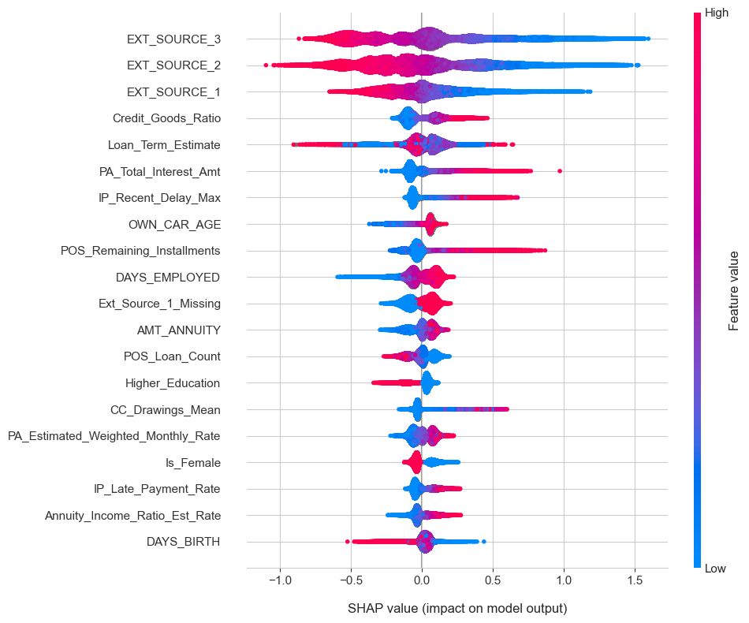

```python
def features_impact(model):
    warnings.filterwarnings("ignore", message="LightGBM binary classifier with TreeExplainer shap values output has changed")
    explainer = shap.TreeExplainer(model)
    shap_values = explainer.shap_values(X_test)
    return shap_values

def plot_summary_plot(model):
    shap_values = features_impact(model)
    shap.summary_plot(shap_values, X_test, plot_size=(10, 8), show=False, max_display=20)
    ax = plt.gca()
    ax.tick_params(axis='y', labelsize=11)
    ax.tick_params(axis='x', labelsize=11)
    plt.xlabel("SHAP value (impact on model output)", fontsize=12, labelpad=15)
    plt.tight_layout()
    plt.show()

plot_summary_plot(light_gbm['best_model'])
```

# Key Findings

- Historical borrowing behavior features were more predictive than many application-level variables, highlighting the importance of external credit history signals.
- Interest-related and repayment-derived features from previous applications emerged as some of the strongest predictors in the model.
- Credit card utilization variables provided meaningful predictive signal despite relatively high levels of missingness.
- Careful feature aggregation strategies were critical for extracting signal from highly granular and sparse historical datasets.
- Feature representation choices had a greater impact on model performance than simply increasing the number of raw features.

# Limitations

Computational constraints limited experimentation with more complex model ensembles. In particular, XGBoost could not be evaluated under the same experimental setup and hyperparameter search space used for LightGBM due to higher computational requirements.

# Conclusions

This project successfully integrated multiple historical credit datasets into a unified predictive framework. Through extensive feature engineering and model tuning, the final LightGBM model achieved a ROC-AUC of approximately 0.7825, demonstrating strong discriminative performance in ranking applicants by default risk. The modeling approach prioritized minority class detection through class weighting, which improved ranking performance but resulted in less well-calibrated probability estimates and relatively low absolute precision at moderate recall levels, despite a clear improvement over a random baseline. Overall, the results highlight the value of combining application data with historical credit behavior, as well as the importance of domain-driven feature engineering in credit risk modeling tasks.